# MNRC MS

This is an [R Markdown](http://rmarkdown.rstudio.com) Notebook associated with the following manuscript: A recombinant mapping yeast population identifies mitotic growth loci influencing mtDNA instability through mitonuclear interactions Tuc H.M. Nguyen, Austen Tinz-Burdick, Meghan Lenhardt, Margaret Geertz, Franchesca Ramirez, Mark Schwartz, Michael Toledano1, Brooke Bonney, Benjamin Gaebler, Weiwei Liu, John F. Wolters, Ken Chiu, Anthony C. Fiumera, Heather L. Fiumera

Final figures edited in Inkscape.

```r
libraries<-c("car", "dplyr", "ggplot2", "ggpubr", "multcomp", "multcompView","tidyverse", "mixlm")
lapply(libraries, require, character.only = TRUE )
```

```
## [[1]]
## [1] TRUE
##
## [[2]]
## [1] TRUE
##
## [[3]]
## [1] TRUE
##
## [[4]]
## [1] TRUE
##
## [[5]]
## [1] TRUE
##
## [[6]]
## [1] TRUE
##
## [[7]]
## [1] TRUE
##
## [[8]]
## [1] TRUE
```

##### import data for Fig 1 and Table S2, set factors and classes

```r
#import data
data.wildisolates<-read.csv("parental_pet.csv", header = TRUE, stringsAsFactors = FALSE)
data.S288c<-read.csv("S288c_pet.csv", header = TRUE, stringsAsFactors = FALSE)
#set factors
data.wildisolates$StrainID<-as.factor(data.wildisolates$StrainID)
data.wildisolates$Nuclear<-as.factor(data.wildisolates$Nuclear)
data.wildisolates$NucPop<-as.factor(data.wildisolates$NucPop)
data.wildisolates$Mito<-as.factor(data.wildisolates$Mito)
data.wildisolates$MitoPop<-as.factor(data.wildisolates$MitoPop)
data.wildisolates$og_v_syn<-as.factor(data.wildisolates$og_v_syn)
data.wildisolates$Genotype<-as.factor(data.wildisolates$Genotype)
#set classes
data.wildisolates$Petite<-as.numeric(data.wildisolates$Petite)
data.wildisolates$Grande<-as.numeric(data.wildisolates$Grande)
data.wildisolates$Total<-as.numeric(data.wildisolates$Total)
```

### Fig 1

#### Genetic variation contributes to mtDNA loss.

Petite frequencies of S. cerevisiae wild isolates as boxplots. The populations as broadly defined in PMCID: 2659681, 6784862, and 4417123

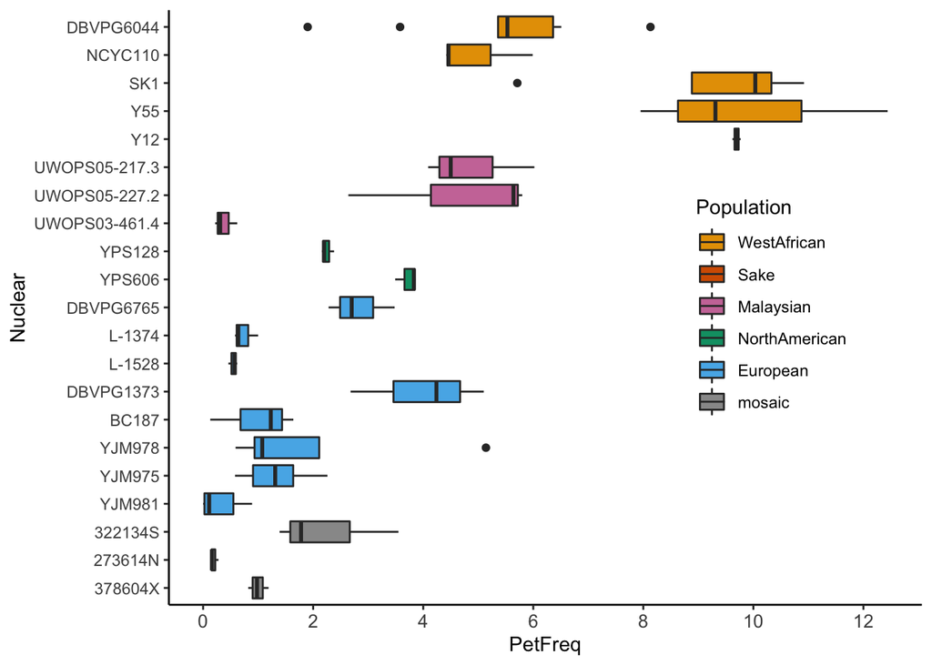

```r
#reorganize isolates for a certain order
data.wildisolates$Nuclear <- factor(data.wildisolates$Nuclear, levels=c("378604X","273614N","322134S","YJM981","YJM975","YJM978","BC187","DBVPG1373","L-1528","L-1374","DBVPG6765","YPS606","YPS128","UWOPS03-461.4","UWOPS05-227.2","UWOPS05-217.3","Y12","Y55","SK1","NCYC110","DBVPG6044"))
#set colorblind palette
cbbPalette2 <- c("WestAfrican" = "#E69F00","Sake" ="#D55E00","Malaysian"= "#CC79A7", "NorthAmerican"="#009E73","European"="#56B4E9" ,"mosaic"="#999999")

Fig1<-ggplot(data.wildisolates,aes(x=Nuclear,y=PetFreq,fill=NucPop))+geom_boxplot()+
  theme_bw()+
  theme(plot.background = element_blank(),panel.grid.major = element_blank(), panel.grid.minor = element_blank(),panel.border = element_blank() ) +
  theme(axis.line = element_line(color = 'black'))+
  theme(axis.text.x = element_text(size = 10)) +scale_fill_manual(values=cbbPalette2)+
  scale_y_continuous(breaks=seq(0,12,2))+
  theme(legend.position = c(0.8,0.5))+
  guides(fill=guide_legend(title="Population"))+
  coord_flip()
Fig1
```

Figure 1 insert for S288c

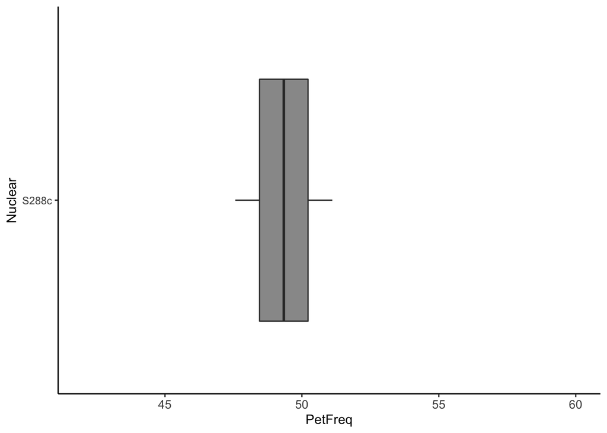

```r
#added as an insert in Inkscape
#plotted in the same x axis spacing as above
bp_S288c<-ggplot(data.S288c,aes(x=Nuclear,y=PetFreq,fill=NucPop))+geom_boxplot()+
  theme_bw()+
  theme(plot.background = element_blank(),panel.grid.major = element_blank(), panel.grid.minor = element_blank(),panel.border = element_blank() ) +
  theme(axis.line = element_line(color = 'black'))+
  theme(axis.text.x = element_text(size = 10)) +scale_fill_manual(values=cbbPalette2)+
  ylim(42,60)+
  theme(legend.position = "none") +coord_flip()
bp_S288c
```

#### Table S2: ANOVA #### Petite frequencies vary by strain and population

Are the differences in petite frequencies due to genetic variation in individuals isolates and/or populations?

```r
#The different numbers of petite/grande colonies counted in each assay are taken into account using cbind function
#the family=binomial accounts for non-normal distribution of petite frequencies
#the variable "Nuclear" is used instead of "StrainID" because there are both mata and x versions of some strains

FM.cbind<-glm(cbind(data.wildisolates$Petite,data.wildisolates$Grande)~data.wildisolates$NucPop/data.wildisolates$Nuclear, family=binomial)

anova(FM.cbind, test="Chisq")
```

|  | Df | Deviance | Resid. Df | Resid. Dev | Pr(>Chi) |
| --- | --- | --- | --- | --- | --- |
| NULL | NA | NA | 76 | 4188.8641 | NA |
| data.wildisolates$NucPop | 5 | 2705.213 | 71 | 1483.6512 | 0.000000e+00 |
| data.wildisolates$NucPop:data.wildisolates$Nuclear | 15 | 1103.468 | 56 | 380.1835 | 8.695223e-226 |

#### Petite frequency averages for each population

```r
pop.means<-data.frame(tapply(predict(FM.cbind, type = "response"), data.wildisolates$NucPop, mean))
pop.means
```

|  | tapply.predict.FM.cbind..type....response....data.wildisolates.NucPop.. |
| --- | --- |
| European | 0.01364125 |
| Malaysian | 0.03287184 |
| mosaic | 0.01048969 |
| NorthAmerican | 0.02991590 |
| Sake | 0.09704185 |
| WestAfrican | 0.06926128 |

### Fig 2A,B, Table S3

#### Mitotype influences on petite frequencies are influenced by M4 GC clusters

This section contains the analyses described in Figure 2A and B and Table S3.

Analyzes the petite frequencies of strains with the Y55 nuclear genotype with different mtDNAs

##### import data and set factors

```r
data.Y55<-read.csv("data.Y55.csv", header = TRUE, stringsAsFactors = FALSE)
#set factors
data.Y55$StrainID<-as.factor(data.Y55$StrainID)
data.Y55$Nuclear<-as.factor(data.Y55$Nuclear)
data.Y55$NucPop<-as.factor(data.Y55$NucPop)
data.Y55$Mito<-as.factor(data.Y55$Mito)
data.Y55$MitoPop<-as.factor(data.Y55$MitoPop)
data.Y55$og_v_syn<-as.factor(data.Y55$og_v_syn)
data.Y55$Genotype<-as.factor(data.Y55$Genotype)
#set classes
data.Y55$Petite<-as.numeric(data.Y55$Petite)
data.Y55$Grande<-as.numeric(data.Y55$Grande)
data.Y55$Total<-as.numeric(data.Y55$Total)
```

#### Petite frequencies averages for each genotype

```r
aggregate(PetFreq~Mito,data=data.Y55,mean)
```

| Mito | PetFreq |
| --- | --- |
| 273614N | 7.326667 |
| 322134S | 9.520000 |
| BC187 | 13.486667 |
| DBVPG1373 | 8.666667 |
| DBVPG6044 | 14.280000 |
| L-1528 | 10.556667 |
| NCYC110 | 31.046667 |
| SK1 | 20.290000 |
| UWOPS83-787.3 | 5.523333 |
| UWOPS87-2421 | 18.820000 |

[output cut: 8 more lines]

#### Table S3: ANOVA

##### mtDNAs influence petite frequencies in the Y55 nuclear background

```r
#Table S3 anova... Does mtDNA variation contribute to petite frequencies?
FM.cbind2<-glm(cbind(data.Y55$Petite,data.Y55$Grande)~data.Y55$Mito, family=binomial)
anova(FM.cbind2, test="Chisq")
```

|  | Df | Deviance | Resid. Df | Resid. Dev | Pr(>Chi) |
| --- | --- | --- | --- | --- | --- |
| NULL | NA | NA | 57 | 7079.168 | NA |
| data.Y55$Mito | 17 | 5196.041 | 40 | 1883.127 | 0 |

### Correlations between mtDNA features and petite frequencies

mtDNA analyses and correlations

This sections contains the analyses for Fig 2A,2B and correlations described in text

##### import and prepare data

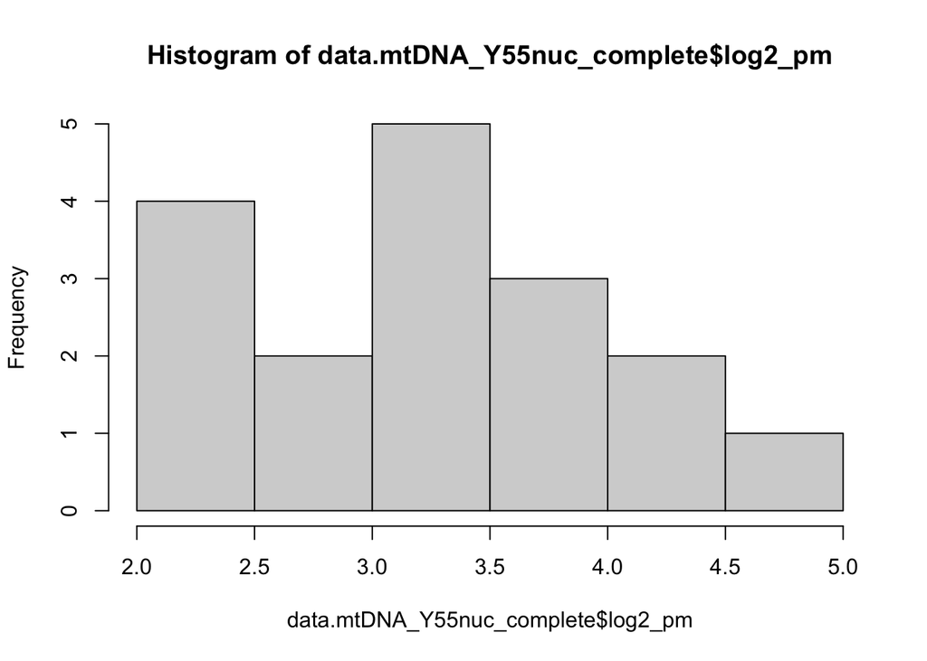

```r
data.mtDNA_full<-read.table("nY55_pet_gc_intron_3.txt", header = TRUE, stringsAsFactors = FALSE)
data.mtDNA_full$log2_pm<-log2(data.mtDNA_full$petfreq_mean)
#subset data to just those that have pet freq in the Y55 mtDNA for analyzed mtDNAs
data.mtDNA_Y55nuc<-data.mtDNA_full%>%dplyr::select(petfreq_mean,log2_pm, mtDNA,mtPop,Length,GC_percent,TotalGCcount,total_intronlength,M1,M2,M3,M4,M1p,M2p,M2pp,G,V,U)
#remove rows with missing values
  data.mtDNA_Y55nuc_complete<-data.mtDNA_Y55nuc[complete.cases(data.mtDNA_Y55nuc),]
#test to see if normally distributed
  hist(data.mtDNA_Y55nuc_complete$log2_pm)
```

```r
  shapiro.test(data.mtDNA_Y55nuc_complete$log2_pm)
```

```
##
##  Shapiro-Wilk normality test
##
## data:  data.mtDNA_Y55nuc_complete$log2_pm
## W = 0.9448, p-value = 0.3796
```

### Fig 2A

#### Plot

Plots the petite frequencies of strains with the Y55 nuclear genotype and different mtDNAs vs. mtDNA GC content

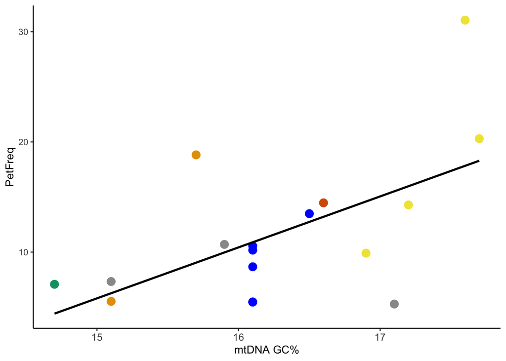

```r
cols2<-c("WineEuro"= "blue","Malaysian" ="#E69F00","mosaic"="#999999", "NthAm"="#009E73", "WestAfr" = "#F0E442", "Sake" = "#D55E00")
Fig2A<-ggplot(data=data.mtDNA_Y55nuc_complete, aes(x = GC_percent, y =petfreq_mean)) +
                geom_point(aes(color=mtPop),size=3.5) +
                scale_color_manual(values=cols2)+
                theme_bw()+
                theme(plot.background = element_blank(),panel.grid.major = element_blank(), panel.grid.minor = element_blank(),panel.border = element_blank() ) +
                theme(axis.line = element_line(color = 'black'))+
                theme(axis.text.x = element_text(size = 10))+
                theme(legend.position = "none")+
                geom_smooth(method = "lm", se = FALSE, color="black")+
                labs(x="mtDNA GC%",y="PetFreq")+theme(legend.position="none")
Fig2A
```

#### Correlation for Fig 2A: Correlation between petite frequency and GC percent

```r
RM.GCp<-lm(data.mtDNA_Y55nuc_complete$petfreq_mean~data.mtDNA_Y55nuc_complete$GC_percent)
        anova(RM.GCp) #GC_percent p =0.01341 *
```

|  | Df | Sum Sq | Mean Sq | F value | Pr(>F) |
| --- | --- | --- | --- | --- | --- |
| data.mtDNA_Y55nuc_complete$GC_percent | 1 | 251.0853 | 251.08530 | 7.849625 | 0.01341314 |
| Residuals | 15 | 479.8037 | 31.98691 | NA | NA |

```r
        summary(RM.GCp) #R^2 = 0.3435
```

```
##
## Call:
## lm(formula = data.mtDNA_Y55nuc_complete$petfreq_mean ~ data.mtDNA_Y55nuc_complete$GC_percent)
##
## Residuals:
##      Min       1Q   Median       3Q      Max
## -10.2315  -2.2226  -0.3326   1.2660  13.2191
##
## Coefficients:
##                                       Estimate Std. Error t value Pr(>|t|)
## (Intercept)                            -63.582     26.897  -2.364   0.0320 *
## data.mtDNA_Y55nuc_complete$GC_percent    4.626      1.651   2.802   0.0134 *
## ---
## Signif. codes:  0 '***' 0.001 '**' 0.01 '*' 0.05 '.' 0.1 ' ' 1
##
## s: 5.656 on 15 degrees of freedom
## Multiple R-squared: 0.3435,
## Adjusted R-squared: 0.2998
## F-statistic:  7.85 on 1 and 15 DF,  p-value: 0.01341
```

```r
        Anova(RM.GCp) #GC_percent p =0.01341
```

|  | Sum Sq | Df | F value | Pr(>F) |
| --- | --- | --- | --- | --- |
| data.mtDNA_Y55nuc_complete$GC_percent | 251.0853 | 1 | 7.849625 | 0.01341314 |
| Residuals | 479.8037 | 15 | NA | NA |

```r
        cor.test.gcppet<-cor.test(data.mtDNA_Y55nuc_complete$GC_percent,data.mtDNA_Y55nuc_complete$petfreq_mean)
        cor.test.gcppet #r=0.5861
```

```
##
##  Pearson's product-moment correlation
##
## data:  data.mtDNA_Y55nuc_complete$GC_percent and data.mtDNA_Y55nuc_complete$petfreq_mean
## t = 2.8017, df = 15, p-value = 0.01341
## alternative hypothesis: true correlation is not equal to 0
## 95 percent confidence interval:
##  0.1468400 0.8322935
## sample estimates:
##       cor
## 0.5861178
```

```r
        cor.test.gcppet$p.value #GCpercent p = 0.01341*
```

```
## [1] 0.01341314
```

```r
        cor.test.gcppet.p<-round(cor.test.gcppet$p.value,3)
        cor.test.gcppet.p #p=0.013 *
```

```
## [1] 0.013
```

```r
        cor.test.gcppet$estimate
```

```
##       cor
## 0.5861178
```

```r
        cor.test.gcpet.r<-round(cor.test.gcppet$estimate)
        cor.test.gcpet.r
```

```
## cor
##   1
```

```r
        gcppet.r<-round(cor.test.gcppet$estimate,2)
        gcppet.r2<-round(cor.test.gcppet$estimate^2,2)
        gcppet.r
```

```
##  cor
## 0.59
```

```r
        gcppet.r2
```

```
##  cor
## 0.34
```

### Fig 2B

#### petite frequency vs. M4 clusters

Plots the petite frequencies of strains with the Y55 nuclear genotype and different mtDNAs vs. the numbers of M4-type GC clusters

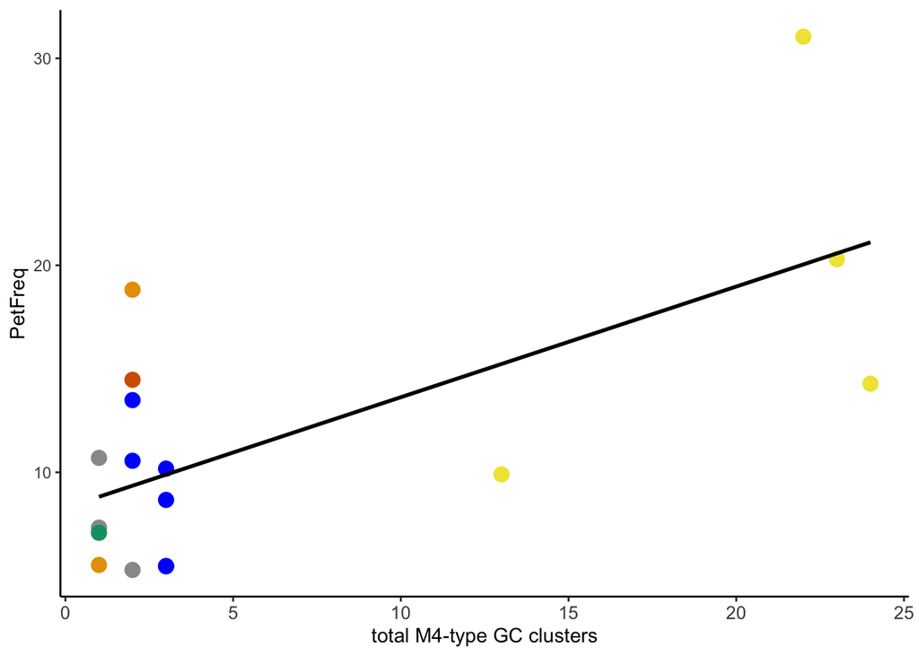

```r
Fig2B<-ggplot(data=data.mtDNA_Y55nuc_complete, aes(x = M4, y =petfreq_mean)) +
                geom_point(aes(color=mtPop),size=3.5) +
                scale_color_manual(values=cols2)+
                theme_bw()+
                theme(plot.background = element_blank(),panel.grid.major = element_blank(), panel.grid.minor = element_blank(),panel.border = element_blank() ) +
                theme(axis.line = element_line(color = 'black'))+
                theme(axis.text.x = element_text(size = 10))+
                theme(legend.position = "none")+
                geom_smooth(method = "lm", se = FALSE, color="black")+
                labs(x="total M4-type GC clusters",y="PetFreq")+theme(legend.position="none")
Fig2B
```

#### Correlation for Fig 2B

#### Correlation between petite frequency and M4 cluster numbers

```r
RM.M4<-lm(data.mtDNA_Y55nuc_complete$petfreq_mean~data.mtDNA_Y55nuc_complete$M4)
        anova(RM.M4) #p= 0.003568 **
```

|  | Df | Sum Sq | Mean Sq | F value | Pr(>F) |
| --- | --- | --- | --- | --- | --- |
| data.mtDNA_Y55nuc_complete$M4 | 1 | 323.4216 | 323.4216 | 11.90604 | 0.003568085 |
| Residuals | 15 | 407.4675 | 27.1645 | NA | NA |

```r
        summary(RM.M4) #R^2 = 0.4425
```

```
##
## Call:
## lm(formula = data.mtDNA_Y55nuc_complete$petfreq_mean ~ data.mtDNA_Y55nuc_complete$M4)
##
## Residuals:
##    Min     1Q Median     3Q    Max
## -6.832 -4.068 -1.219  1.880 11.004
##
## Coefficients:
##                               Estimate Std. Error t value Pr(>|t|)
## (Intercept)                     8.2824     1.6020   5.170 0.000114 ***
## data.mtDNA_Y55nuc_complete$M4   0.5345     0.1549   3.451 0.003568 **
## ---
## Signif. codes:  0 '***' 0.001 '**' 0.01 '*' 0.05 '.' 0.1 ' ' 1
##
## s: 5.212 on 15 degrees of freedom
## Multiple R-squared: 0.4425,
## Adjusted R-squared: 0.4053
## F-statistic: 11.91 on 1 and 15 DF,  p-value: 0.003568
```

```r
        Anova(RM.M4) #M4 p=
```

|  | Sum Sq | Df | F value | Pr(>F) |
| --- | --- | --- | --- | --- |
| data.mtDNA_Y55nuc_complete$M4 | 323.4216 | 1 | 11.90604 | 0.003568085 |
| Residuals | 407.4675 | 15 | NA | NA |

```r
        cor.test.m4<-cor.test(data.mtDNA_Y55nuc_complete$M4,data.mtDNA_Y55nuc_complete$petfreq_mean)
        cor.test.m4 #r=0.0.66521
```

```
##
##  Pearson's product-moment correlation
##
## data:  data.mtDNA_Y55nuc_complete$M4 and data.mtDNA_Y55nuc_complete$petfreq_mean
## t = 3.4505, df = 15, p-value = 0.003568
## alternative hypothesis: true correlation is not equal to 0
## 95 percent confidence interval:
##  0.2713116 0.8682496
## sample estimates:
##     cor
## 0.66521
```

```r
        cor.test.m4$p.value #M4 p =
```

```
## [1] 0.003568085
```

```r
        cor.test.m4.p<-round(cor.test.m4$p.value,3)
        cor.test.m4.p #m4 p=0.004 **
```

```
## [1] 0.004
```

```r
        m4.r<-round(cor.test.m4$estimate,2)
        m4.r2<-round(cor.test.m4$estimate^2,2)
        m4.r
```

```
##  cor
## 0.67
```

```r
        m4.r2
```

```
##  cor
## 0.44
```

##### Other Correlations, some described in text

Do GC cluster numbers and GC% correlate with each other? (yes)

```r
FM.gcc.gcp<-lm(data.mtDNA_Y55nuc_complete$GC_percent~data.mtDNA_Y55nuc_complete$TotalGCcount)
      anova(FM.gcc.gcp)
```

|  | Df | Sum Sq | Mean Sq | F value | Pr(>F) |
| --- | --- | --- | --- | --- | --- |
| data.mtDNA_Y55nuc_complete$TotalGCcount | 1 | 10.541061 | 10.54106055 | 132.3995 | 7.657339e-09 |
| Residuals | 15 | 1.194234 | 0.07961557 | NA | NA |

```r
      summary(FM.gcc.gcp)
```

```
##
## Call:
## lm(formula = data.mtDNA_Y55nuc_complete$GC_percent ~ data.mtDNA_Y55nuc_complete$TotalGCcount)
##
## Residuals:
##     Min      1Q  Median      3Q     Max
## -0.4525 -0.2200  0.1045  0.1472  0.4147
##
## Coefficients:
##                                          Estimate Std. Error t value Pr(>|t|)
## (Intercept)                             11.861832   0.389217   30.48 6.59e-15
## data.mtDNA_Y55nuc_complete$TotalGCcount  0.026224   0.002279   11.51 7.66e-09
##
## (Intercept)                             ***
## data.mtDNA_Y55nuc_complete$TotalGCcount ***
## ---
## Signif. codes:  0 '***' 0.001 '**' 0.01 '*' 0.05 '.' 0.1 ' ' 1
##
## s: 0.2822 on 15 degrees of freedom
## Multiple R-squared: 0.8982,
## Adjusted R-squared: 0.8915
## F-statistic: 132.4 on 1 and 15 DF,  p-value: 7.657e-09
```

```r
      cor.test.gccgcp<-cor.test(data.mtDNA_Y55nuc_complete$TotalGCcount,data.mtDNA_Y55nuc_complete$GC_percent)
      cor.test.gccgcp
```

```
##
##  Pearson's product-moment correlation
##
## data:  data.mtDNA_Y55nuc_complete$TotalGCcount and data.mtDNA_Y55nuc_complete$GC_percent
## t = 11.506, df = 15, p-value = 7.657e-09
## alternative hypothesis: true correlation is not equal to 0
## 95 percent confidence interval:
##  0.8579176 0.9813575
## sample estimates:
##      cor
## 0.947753
```

```r
      cor.test.gccgcp$p.value
```

```
## [1] 7.657339e-09
```

```r
      #yes, GC cluster numbers correlate with GC percent
```

Does GC$ and total mtDNAlength correlate? (yes)

```r
FM.gcpl<-lm(data.mtDNA_Y55nuc_complete$Length~data.mtDNA_Y55nuc_complete$GC_percent)
      anova(FM.gcpl)
```

|  | Df | Sum Sq | Mean Sq | F value | Pr(>F) |
| --- | --- | --- | --- | --- | --- |
| data.mtDNA_Y55nuc_complete$GC_percent | 1 | 93127319 | 93127319 | 7.539543 | 0.01501181 |
| Residuals | 15 | 185277776 | 12351852 | NA | NA |

```r
      summary(FM.gcpl)
```

```
##
## Call:
## lm(formula = data.mtDNA_Y55nuc_complete$Length ~ data.mtDNA_Y55nuc_complete$GC_percent)
##
## Residuals:
##     Min      1Q  Median      3Q     Max
## -4612.8 -2319.2  -496.2   983.8 10784.8
##
## Coefficients:
##                                       Estimate Std. Error t value Pr(>|t|)
## (Intercept)                              35915      16714   2.149   0.0484 *
## data.mtDNA_Y55nuc_complete$GC_percent     2817       1026   2.746   0.0150 *
## ---
## Signif. codes:  0 '***' 0.001 '**' 0.01 '*' 0.05 '.' 0.1 ' ' 1
##
## s: 3515 on 15 degrees of freedom
## Multiple R-squared: 0.3345,
## Adjusted R-squared: 0.2901
## F-statistic:  7.54 on 1 and 15 DF,  p-value: 0.01501
```

```r
      cor.test.gcpl<-cor.test(data.mtDNA_Y55nuc_complete$GC_percent,data.mtDNA_Y55nuc_complete$Length)
      cor.test.gcpl
```

```
##
##  Pearson's product-moment correlation
##
## data:  data.mtDNA_Y55nuc_complete$GC_percent and data.mtDNA_Y55nuc_complete$Length
## t = 2.7458, df = 15, p-value = 0.01501
## alternative hypothesis: true correlation is not equal to 0
## 95 percent confidence interval:
##  0.1353403 0.8286526
## sample estimates:
##       cor
## 0.5783623
```

```r
      cor.test.gcpl$p.value
```

```
## [1] 0.01501181
```

```r
      #yes, GC percent and mtDNA length correlate
```

Do GC cluster numbers (total) correlate with total mtDNA length? (yes)

```r
 # do the total number of GC clusters correlate with mtDNA length?
      FM.gcc.length<-lm(data.mtDNA_Y55nuc_complete$Length~data.mtDNA_Y55nuc_complete$TotalGCcount)
      anova(FM.gcc.length)
```

|  | Df | Sum Sq | Mean Sq | F value | Pr(>F) |
| --- | --- | --- | --- | --- | --- |
| data.mtDNA_Y55nuc_complete$TotalGCcount | 1 | 135193265 | 135193265 | 14.16014 | 0.001880282 |
| Residuals | 15 | 143211831 | 9547455 | NA | NA |

```r
      summary(FM.gcc.length)
```

```
##
## Call:
## lm(formula = data.mtDNA_Y55nuc_complete$Length ~ data.mtDNA_Y55nuc_complete$TotalGCcount)
##
## Residuals:
##     Min      1Q  Median      3Q     Max
## -4143.8 -1695.7  -462.5   631.3  8530.4
##
## Coefficients:
##                                         Estimate Std. Error t value Pr(>|t|)
## (Intercept)                             65960.88    4262.23  15.476 1.25e-10
## data.mtDNA_Y55nuc_complete$TotalGCcount    93.92      24.96   3.763  0.00188
##
## (Intercept)                             ***
## data.mtDNA_Y55nuc_complete$TotalGCcount **
## ---
## Signif. codes:  0 '***' 0.001 '**' 0.01 '*' 0.05 '.' 0.1 ' ' 1
##
## s: 3090 on 15 degrees of freedom
## Multiple R-squared: 0.4856,
## Adjusted R-squared: 0.4513
## F-statistic: 14.16 on 1 and 15 DF,  p-value: 0.00188
```

```r
      Anova(FM.gcc.length)
```

|  | Sum Sq | Df | F value | Pr(>F) |
| --- | --- | --- | --- | --- |
| data.mtDNA_Y55nuc_complete$TotalGCcount | 135193265 | 1 | 14.16014 | 0.001880282 |
| Residuals | 143211831 | 15 | NA | NA |

```r
      cor.test.gccl<-cor.test(data.mtDNA_Y55nuc_complete$TotalGCcount,data.mtDNA_Y55nuc_complete$Length)
      cor.test.gccl
```

```
##
##  Pearson's product-moment correlation
##
## data:  data.mtDNA_Y55nuc_complete$TotalGCcount and data.mtDNA_Y55nuc_complete$Length
## t = 3.763, df = 15, p-value = 0.00188
## alternative hypothesis: true correlation is not equal to 0
## 95 percent confidence interval:
##  0.3250890 0.8820597
## sample estimates:
##       cor
## 0.6968494
```

```r
      cor.test.gccl$p.value
```

```
## [1] 0.001880282
```

```r
      #yes, GC% correlates with total mtDNA length
```

Does total intron length correlate with total mtDNA length? (yes)

```r
FM.ibp.length<-lm(data.mtDNA_Y55nuc_complete$Length~data.mtDNA_Y55nuc_complete$total_intronlength)
      anova(FM.ibp.length)
```

|  | Df | Sum Sq | Mean Sq | F value | Pr(>F) |
| --- | --- | --- | --- | --- | --- |
| data.mtDNA_Y55nuc_complete$total_intronlength | 1 | 214983030 | 214983030 | 50.8458 | 3.445509e-06 |
| Residuals | 15 | 63422065 | 4228138 | NA | NA |

```r
      summary(FM.ibp.length)
```

```
##
## Call:
## lm(formula = data.mtDNA_Y55nuc_complete$Length ~ data.mtDNA_Y55nuc_complete$total_intronlength)
##
## Residuals:
##     Min      1Q  Median      3Q     Max
## -3669.2 -1591.1   241.1   633.3  4658.8
##
## Coefficients:
##                                                Estimate Std. Error t value
## (Intercept)                                   6.515e+04  2.381e+03  27.366
## data.mtDNA_Y55nuc_complete$total_intronlength 1.206e+00  1.691e-01   7.131
##                                               Pr(>|t|)
## (Intercept)                                   3.22e-14 ***
## data.mtDNA_Y55nuc_complete$total_intronlength 3.45e-06 ***
## ---
## Signif. codes:  0 '***' 0.001 '**' 0.01 '*' 0.05 '.' 0.1 ' ' 1
##
## s: 2056 on 15 degrees of freedom
## Multiple R-squared: 0.7722,
## Adjusted R-squared: 0.757
## F-statistic: 50.85 on 1 and 15 DF,  p-value: 3.446e-06
```

```r
      Anova(FM.ibp.length)
```

|  | Sum Sq | Df | F value | Pr(>F) |
| --- | --- | --- | --- | --- |
| data.mtDNA_Y55nuc_complete$total_intronlength | 214983030 | 1 | 50.8458 | 3.445509e-06 |
| Residuals | 63422065 | 15 | NA | NA |

```r
      cor.test.ibp<-cor.test(data.mtDNA_Y55nuc_complete$total_intronlength,data.mtDNA_Y55nuc_complete$Length)
      cor.test.ibp
```

```
##
##  Pearson's product-moment correlation
##
## data:  data.mtDNA_Y55nuc_complete$total_intronlength and data.mtDNA_Y55nuc_complete$Length
## t = 7.1306, df = 15, p-value = 3.446e-06
## alternative hypothesis: true correlation is not equal to 0
## 95 percent confidence interval:
##  0.6891919 0.9557260
## sample estimates:
##       cor
## 0.8787463
```

```r
      cor.test.ibp$p.value
```

```
## [1] 3.445509e-06
```

```r
      #yes, intron lengths correlate with total mtDNA length
```

Does total intron length correlate with total GC cluster count? (no)

```r
FM.ibpgcc<-lm(data.mtDNA_Y55nuc_complete$total_intronlength~data.mtDNA_Y55nuc_complete$TotalGCcount)
      anova(FM.ibpgcc)
```

|  | Df | Sum Sq | Mean Sq | F value | Pr(>F) |
| --- | --- | --- | --- | --- | --- |
| data.mtDNA_Y55nuc_complete$TotalGCcount | 1 | 28614557 | 28614557 | 3.597301 | 0.07729987 |
| Residuals | 15 | 119316779 | 7954452 | NA | NA |

```r
      summary(FM.ibpgcc)
```

```
##
## Call:
## lm(formula = data.mtDNA_Y55nuc_complete$total_intronlength ~
##     data.mtDNA_Y55nuc_complete$TotalGCcount)
##
## Residuals:
##     Min      1Q  Median      3Q     Max
## -4203.3 -1094.0  -476.1   536.8  8572.3
##
## Coefficients:
##                                         Estimate Std. Error t value Pr(>|t|)
## (Intercept)                              6505.79    3890.43   1.672   0.1152
## data.mtDNA_Y55nuc_complete$TotalGCcount    43.21      22.78   1.897   0.0773 .
## ---
## Signif. codes:  0 '***' 0.001 '**' 0.01 '*' 0.05 '.' 0.1 ' ' 1
##
## s: 2820 on 15 degrees of freedom
## Multiple R-squared: 0.1934,
## Adjusted R-squared: 0.1397
## F-statistic: 3.597 on 1 and 15 DF,  p-value: 0.0773
```

```r
      cor.test.ibpgcc<-cor.test(data.mtDNA_Y55nuc_complete$TotalGCcount,data.mtDNA_Y55nuc_complete$total_intronlength)
      cor.test.ibpgcc
```

```
##
##  Pearson's product-moment correlation
##
## data:  data.mtDNA_Y55nuc_complete$TotalGCcount and data.mtDNA_Y55nuc_complete$total_intronlength
## t = 1.8967, df = 15, p-value = 0.0773
## alternative hypothesis: true correlation is not equal to 0
## 95 percent confidence interval:
##  -0.05178294  0.75983117
## sample estimates:
##       cor
## 0.4398083
```

```r
      cor.test.ibpgcc$p.value
```

```
## [1] 0.07729987
```

```r
      #no, the total intron length does not correlate with GC cluster count
```

Does total intron length correlate with total GC percent? (no)

```r
FM.ibpgcp<-lm(data.mtDNA_Y55nuc_complete$total_intronlength~data.mtDNA_Y55nuc_complete$GC_percent)
      anova(FM.ibpgcp)
```

|  | Df | Sum Sq | Mean Sq | F value | Pr(>F) |
| --- | --- | --- | --- | --- | --- |
| data.mtDNA_Y55nuc_complete$GC_percent | 1 | 12935988 | 12935988 | 1.437382 | 0.2491614 |
| Residuals | 15 | 134995348 | 8999690 | NA | NA |

```r
      summary(FM.ibpgcp)
```

```
##
## Call:
## lm(formula = data.mtDNA_Y55nuc_complete$total_intronlength ~
##     data.mtDNA_Y55nuc_complete$GC_percent)
##
## Residuals:
##     Min      1Q  Median      3Q     Max
## -3369.4 -1458.6  -822.5   211.3  9813.5
##
## Coefficients:
##                                       Estimate Std. Error t value Pr(>|t|)
## (Intercept)                            -3313.0    14267.1  -0.232    0.820
## data.mtDNA_Y55nuc_complete$GC_percent   1049.9      875.7   1.199    0.249
##
## s: 3000 on 15 degrees of freedom
## Multiple R-squared: 0.08745,
## Adjusted R-squared: 0.02661
## F-statistic: 1.437 on 1 and 15 DF,  p-value: 0.2492
```

```r
      cor.test.ibpgcp<-cor.test(data.mtDNA_Y55nuc_complete$GC_percent,data.mtDNA_Y55nuc_complete$total_intronlength)
      cor.test.ibpgcp
```

```
##
##  Pearson's product-moment correlation
##
## data:  data.mtDNA_Y55nuc_complete$GC_percent and data.mtDNA_Y55nuc_complete$total_intronlength
## t = 1.1989, df = 15, p-value = 0.2492
## alternative hypothesis: true correlation is not equal to 0
## 95 percent confidence interval:
##  -0.2155721  0.6797435
## sample estimates:
##       cor
## 0.2957125
```

```r
      cor.test.ibpgcp$p.value
```

```
## [1] 0.2491614
```

```r
      #no, the total intron length does not correlate with GC cluster count
```

Do petite frequencies correlate with total GC cluster numbers? (no)

```r
 #Pet vs TotalGC cluster
        RM.GCcluster<-lm(data.mtDNA_Y55nuc_complete$petfreq_mean~data.mtDNA_Y55nuc_complete$TotalGCcount)
        anova(RM.GCcluster)
```

|  | Df | Sum Sq | Mean Sq | F value | Pr(>F) |
| --- | --- | --- | --- | --- | --- |
| data.mtDNA_Y55nuc_complete$TotalGCcount | 1 | 144.3776 | 144.37758 | 3.692449 | 0.07386781 |
| Residuals | 15 | 586.5114 | 39.10076 | NA | NA |

```r
        summary(RM.GCcluster)
```

```
##
## Call:
## lm(formula = data.mtDNA_Y55nuc_complete$petfreq_mean ~ data.mtDNA_Y55nuc_complete$TotalGCcount)
##
## Residuals:
##      Min       1Q   Median       3Q      Max
## -11.1392  -2.8345  -1.3316   0.7767  15.9829
##
## Coefficients:
##                                         Estimate Std. Error t value Pr(>|t|)
## (Intercept)                             -4.63806    8.62552  -0.538   0.5987
## data.mtDNA_Y55nuc_complete$TotalGCcount  0.09705    0.05051   1.922   0.0739 .
## ---
## Signif. codes:  0 '***' 0.001 '**' 0.01 '*' 0.05 '.' 0.1 ' ' 1
##
## s: 6.253 on 15 degrees of freedom
## Multiple R-squared: 0.1975,
## Adjusted R-squared: 0.144
## F-statistic: 3.692 on 1 and 15 DF,  p-value: 0.07387
```

```r
        Anova(RM.GCcluster)
```

|  | Sum Sq | Df | F value | Pr(>F) |
| --- | --- | --- | --- | --- |
| data.mtDNA_Y55nuc_complete$TotalGCcount | 144.3776 | 1 | 3.692449 | 0.07386781 |
| Residuals | 586.5114 | 15 | NA | NA |

```r
        cor.test.gcc<-cor.test(data.mtDNA_Y55nuc_complete$TotalGCcount,data.mtDNA_Y55nuc_complete$petfreq_mean)
        cor.test.gcc
```

```
##
##  Pearson's product-moment correlation
##
## data:  data.mtDNA_Y55nuc_complete$TotalGCcount and data.mtDNA_Y55nuc_complete$petfreq_mean
## t = 1.9216, df = 15, p-value = 0.07387
## alternative hypothesis: true correlation is not equal to 0
## 95 percent confidence interval:
##  -0.04602562  0.76225970
## sample estimates:
##       cor
## 0.4444513
```

```r
        cor.test.gcc$p.value
```

```
## [1] 0.07386781
```

```r
        cor.test.gcc.p<-round(cor.test.gcc$p.value,3)
        cor.test.gcc.p
```

```
## [1] 0.074
```

```r
        #no, petite frequency does not correlate with total GC cluster numbers
```

Do petite frequencies correlate with total mtDNA length? (no)

```r
  #Pet vs. Length
        RM.Length<-lm(data.mtDNA_Y55nuc_complete$petfreq_mean~data.mtDNA_Y55nuc_complete$Length)
        anova(RM.Length)
```

|  | Df | Sum Sq | Mean Sq | F value | Pr(>F) |
| --- | --- | --- | --- | --- | --- |
| data.mtDNA_Y55nuc_complete$Length | 1 | 11.30798 | 11.30798 | 0.2357201 | 0.6343297 |
| Residuals | 15 | 719.58104 | 47.97207 | NA | NA |

```r
        summary(RM.Length)
```

```
##
## Call:
## lm(formula = data.mtDNA_Y55nuc_complete$petfreq_mean ~ data.mtDNA_Y55nuc_complete$Length)
##
## Residuals:
##    Min     1Q Median     3Q    Max
## -9.039 -3.748 -1.223  2.244 19.543
##
## Coefficients:
##                                     Estimate Std. Error t value Pr(>|t|)
## (Intercept)                       -4.7972552 33.9761071  -0.141    0.890
## data.mtDNA_Y55nuc_complete$Length  0.0002015  0.0004151   0.486    0.634
##
## s: 6.926 on 15 degrees of freedom
## Multiple R-squared: 0.01547,
## Adjusted R-squared: -0.05016
## F-statistic: 0.2357 on 1 and 15 DF,  p-value: 0.6343
```

```r
        Anova(RM.Length)
```

|  | Sum Sq | Df | F value | Pr(>F) |
| --- | --- | --- | --- | --- |
| data.mtDNA_Y55nuc_complete$Length | 11.30798 | 1 | 0.2357201 | 0.6343297 |
| Residuals | 719.58104 | 15 | NA | NA |

```r
        cor.test.tbp<-cor.test(data.mtDNA_Y55nuc_complete$Length,data.mtDNA_Y55nuc_complete$petfreq_mean)
        cor.test.tbp
```

```
##
##  Pearson's product-moment correlation
##
## data:  data.mtDNA_Y55nuc_complete$Length and data.mtDNA_Y55nuc_complete$petfreq_mean
## t = 0.48551, df = 15, p-value = 0.6343
## alternative hypothesis: true correlation is not equal to 0
## 95 percent confidence interval:
##  -0.3789134  0.5708984
## sample estimates:
##       cor
## 0.1243846
```

```r
        cor.test.tbp$p.value
```

```
## [1] 0.6343297
```

```r
        cor.test.tbp.p<-round(cor.test.tbp$p.value,3)
        cor.test.tbp.p
```

```
## [1] 0.634
```

```r
        #no, petite frequency does not correlate with total mtDNA length
```

Do petite frequencies correlate with intron lengths? (no)

```r
        #Pet vs. Intron Length
        RM.intronbp<-lm(data.mtDNA_Y55nuc_complete$petfreq_mean~data.mtDNA_Y55nuc_complete$total_intronlength)
        anova(RM.intronbp)
```

|  | Df | Sum Sq | Mean Sq | F value | Pr(>F) |
| --- | --- | --- | --- | --- | --- |
| data.mtDNA_Y55nuc_complete$total_intronlength | 1 | 6.096106 | 6.096106 | 0.1261624 | 0.7273897 |
| Residuals | 15 | 724.792912 | 48.319527 | NA | NA |

```r
        summary(RM.intronbp)
```

```
##
## Call:
## lm(formula = data.mtDNA_Y55nuc_complete$petfreq_mean ~ data.mtDNA_Y55nuc_complete$total_intronlength)
##
## Residuals:
##    Min     1Q Median     3Q    Max
## -6.701 -4.601 -1.705  2.306 19.146
##
## Coefficients:
##                                                 Estimate Std. Error t value
## (Intercept)                                   14.4735530  8.0481879   1.798
## data.mtDNA_Y55nuc_complete$total_intronlength -0.0002030  0.0005715  -0.355
##                                               Pr(>|t|)
## (Intercept)                                     0.0923 .
## data.mtDNA_Y55nuc_complete$total_intronlength   0.7274
## ---
## Signif. codes:  0 '***' 0.001 '**' 0.01 '*' 0.05 '.' 0.1 ' ' 1
##
## s: 6.951 on 15 degrees of freedom
## Multiple R-squared: 0.008341,
## Adjusted R-squared: -0.05777
## F-statistic: 0.1262 on 1 and 15 DF,  p-value: 0.7274
```

```r
        Anova(RM.intronbp)
```

|  | Sum Sq | Df | F value | Pr(>F) |
| --- | --- | --- | --- | --- |
| data.mtDNA_Y55nuc_complete$total_intronlength | 6.096106 | 1 | 0.1261624 | 0.7273897 |
| Residuals | 724.792912 | 15 | NA | NA |

```r
        cor.test.ibppet<-cor.test(data.mtDNA_Y55nuc_complete$total_intronlength,data.mtDNA_Y55nuc_complete$petfreq_mean)
        cor.test.ibppet
```

```
##
##  Pearson's product-moment correlation
##
## data:  data.mtDNA_Y55nuc_complete$total_intronlength and data.mtDNA_Y55nuc_complete$petfreq_mean
## t = -0.35519, df = 15, p-value = 0.7274
## alternative hypothesis: true correlation is not equal to 0
## 95 percent confidence interval:
##  -0.5479205  0.4071916
## sample estimates:
##         cor
## -0.09132729
```

```r
        cor.test.ibppet$p.value
```

```
## [1] 0.7273897
```

```r
        #no, total intron length does not correlate with petfreq
```

Do petite frequencies correlate with specific GC cluster types? (only M4 class)

```r
        #M1 cluster vs. petfreq_mean
        RM.M1<-lm(data.mtDNA_Y55nuc_complete$petfreq_mean~data.mtDNA_Y55nuc_complete$M1)
        anova(RM.M1)
```

|  | Df | Sum Sq | Mean Sq | F value | Pr(>F) |
| --- | --- | --- | --- | --- | --- |
| data.mtDNA_Y55nuc_complete$M1 | 1 | 62.79973 | 62.79973 | 1.409985 | 0.253523 |
| Residuals | 15 | 668.08928 | 44.53929 | NA | NA |

```r
        summary(RM.M1)
```

```
##
## Call:
## lm(formula = data.mtDNA_Y55nuc_complete$petfreq_mean ~ data.mtDNA_Y55nuc_complete$M1)
##
## Residuals:
##    Min     1Q Median     3Q    Max
## -9.029 -2.934 -1.671  1.023 17.761
##
## Coefficients:
##                               Estimate Std. Error t value Pr(>|t|)
## (Intercept)                     2.6043     7.8113   0.333    0.743
## data.mtDNA_Y55nuc_complete$M1   0.2054     0.1730   1.187    0.254
##
## s: 6.674 on 15 degrees of freedom
## Multiple R-squared: 0.08592,
## Adjusted R-squared: 0.02498
## F-statistic:  1.41 on 1 and 15 DF,  p-value: 0.2535
```

```r
        Anova(RM.M1)
```

|  | Sum Sq | Df | F value | Pr(>F) |
| --- | --- | --- | --- | --- |
| data.mtDNA_Y55nuc_complete$M1 | 62.79973 | 1 | 1.409985 | 0.253523 |
| Residuals | 668.08928 | 15 | NA | NA |

```r
        cor.test.m1<-cor.test(data.mtDNA_Y55nuc_complete$M1,data.mtDNA_Y55nuc_complete$petfreq_mean)
        cor.test.m1
```

```
##
##  Pearson's product-moment correlation
##
## data:  data.mtDNA_Y55nuc_complete$M1 and data.mtDNA_Y55nuc_complete$petfreq_mean
## t = 1.1874, df = 15, p-value = 0.2535
## alternative hypothesis: true correlation is not equal to 0
## 95 percent confidence interval:
##  -0.2182716  0.6782166
## sample estimates:
##       cor
## 0.2931252
```

```r
        cor.test.m1$p.value
```

```
## [1] 0.253523
```

```r
        cor.test.m1.p<-round(cor.test.m1$p.value,3)
        cor.test.m1.p
```

```
## [1] 0.254
```

```r
        #not significant

        #M2 cluster vs. petfreq_mean
        RM.M2<-lm(data.mtDNA_Y55nuc_complete$petfreq_mean~data.mtDNA_Y55nuc_complete$M2)
        anova(RM.M2)
```

|  | Df | Sum Sq | Mean Sq | F value | Pr(>F) |
| --- | --- | --- | --- | --- | --- |
| data.mtDNA_Y55nuc_complete$M2 | 1 | 82.50661 | 82.50661 | 1.908749 | 0.1873353 |
| Residuals | 15 | 648.38241 | 43.22549 | NA | NA |

```r
        summary(RM.M2)
```

```
##
## Call:
## lm(formula = data.mtDNA_Y55nuc_complete$petfreq_mean ~ data.mtDNA_Y55nuc_complete$M2)
##
## Residuals:
##      Min       1Q   Median       3Q      Max
## -10.5515  -3.6054  -1.3358   0.7997  17.5870
##
## Coefficients:
##                               Estimate Std. Error t value Pr(>|t|)
## (Intercept)                     3.3652     6.2248   0.541    0.597
## data.mtDNA_Y55nuc_complete$M2   0.2969     0.2149   1.382    0.187
##
## s: 6.575 on 15 degrees of freedom
## Multiple R-squared: 0.1129,
## Adjusted R-squared: 0.05374
## F-statistic: 1.909 on 1 and 15 DF,  p-value: 0.1873
```

```r
        Anova(RM.M2)
```

|  | Sum Sq | Df | F value | Pr(>F) |
| --- | --- | --- | --- | --- |
| data.mtDNA_Y55nuc_complete$M2 | 82.50661 | 1 | 1.908749 | 0.1873353 |
| Residuals | 648.38241 | 15 | NA | NA |

```r
        cor.test.m2<-cor.test(data.mtDNA_Y55nuc_complete$M2,data.mtDNA_Y55nuc_complete$petfreq_mean)
        cor.test.m2
```

```
##
##  Pearson's product-moment correlation
##
## data:  data.mtDNA_Y55nuc_complete$M2 and data.mtDNA_Y55nuc_complete$petfreq_mean
## t = 1.3816, df = 15, p-value = 0.1873
## alternative hypothesis: true correlation is not equal to 0
## 95 percent confidence interval:
##  -0.1725210  0.7030879
## sample estimates:
##      cor
## 0.335984
```

```r
        cor.test.m2$p.value
```

```
## [1] 0.1873353
```

```r
        cor.test.m2.p<-round(cor.test.m2$p.value,3)
        cor.test.m2.p
```

```
## [1] 0.187
```

```r
        #not significant

        #M3 cluster vs. petfreq_mean
        RM.M3<-lm(data.mtDNA_Y55nuc_complete$petfreq_mean~data.mtDNA_Y55nuc_complete$M3)
        anova(RM.M3)
```

|  | Df | Sum Sq | Mean Sq | F value | Pr(>F) |
| --- | --- | --- | --- | --- | --- |
| data.mtDNA_Y55nuc_complete$M3 | 1 | 59.96987 | 59.96987 | 1.34077 | 0.2650034 |
| Residuals | 15 | 670.91915 | 44.72794 | NA | NA |

```r
        summary(RM.M3)
```

```
##
## Call:
## lm(formula = data.mtDNA_Y55nuc_complete$petfreq_mean ~ data.mtDNA_Y55nuc_complete$M3)
##
## Residuals:
##    Min     1Q Median     3Q    Max
## -8.681 -3.830 -1.432  1.498 17.082
##
## Coefficients:
##                               Estimate Std. Error t value Pr(>|t|)
## (Intercept)                     1.4498     8.9812   0.161    0.874
## data.mtDNA_Y55nuc_complete$M3   0.6587     0.5688   1.158    0.265
##
## s: 6.688 on 15 degrees of freedom
## Multiple R-squared: 0.08205,
## Adjusted R-squared: 0.02085
## F-statistic: 1.341 on 1 and 15 DF,  p-value: 0.265
```

```r
        Anova(RM.M3)
```

|  | Sum Sq | Df | F value | Pr(>F) |
| --- | --- | --- | --- | --- |
| data.mtDNA_Y55nuc_complete$M3 | 59.96987 | 1 | 1.34077 | 0.2650034 |
| Residuals | 670.91915 | 15 | NA | NA |

```r
        cor.test.m3<-cor.test(data.mtDNA_Y55nuc_complete$M3,data.mtDNA_Y55nuc_complete$petfreq_mean)
        cor.test.m3
```

```
##
##  Pearson's product-moment correlation
##
## data:  data.mtDNA_Y55nuc_complete$M3 and data.mtDNA_Y55nuc_complete$petfreq_mean
## t = 1.1579, df = 15, p-value = 0.265
## alternative hypothesis: true correlation is not equal to 0
## 95 percent confidence interval:
##  -0.2252060  0.6742588
## sample estimates:
##       cor
## 0.2864447
```

```r
        cor.test.m3$p.value
```

```
## [1] 0.2650034
```

```r
        cor.test.m3.p<-round(cor.test.m3$p.value,3)
        cor.test.m3.p
```

```
## [1] 0.265
```

```r
        #not significant

        #M4 vs. pet freq
        RM.M4<-lm(data.mtDNA_Y55nuc_complete$petfreq_mean~data.mtDNA_Y55nuc_complete$M4)
        anova(RM.M4)
```

|  | Df | Sum Sq | Mean Sq | F value | Pr(>F) |
| --- | --- | --- | --- | --- | --- |
| data.mtDNA_Y55nuc_complete$M4 | 1 | 323.4216 | 323.4216 | 11.90604 | 0.003568085 |
| Residuals | 15 | 407.4675 | 27.1645 | NA | NA |

```r
        summary(RM.M4)
```

```
##
## Call:
## lm(formula = data.mtDNA_Y55nuc_complete$petfreq_mean ~ data.mtDNA_Y55nuc_complete$M4)
##
## Residuals:
##    Min     1Q Median     3Q    Max
## -6.832 -4.068 -1.219  1.880 11.004
##
## Coefficients:
##                               Estimate Std. Error t value Pr(>|t|)
## (Intercept)                     8.2824     1.6020   5.170 0.000114 ***
## data.mtDNA_Y55nuc_complete$M4   0.5345     0.1549   3.451 0.003568 **
## ---
## Signif. codes:  0 '***' 0.001 '**' 0.01 '*' 0.05 '.' 0.1 ' ' 1
##
## s: 5.212 on 15 degrees of freedom
## Multiple R-squared: 0.4425,
## Adjusted R-squared: 0.4053
## F-statistic: 11.91 on 1 and 15 DF,  p-value: 0.003568
```

```r
        Anova(RM.M4)
```

|  | Sum Sq | Df | F value | Pr(>F) |
| --- | --- | --- | --- | --- |
| data.mtDNA_Y55nuc_complete$M4 | 323.4216 | 1 | 11.90604 | 0.003568085 |
| Residuals | 407.4675 | 15 | NA | NA |

```r
        cor.test.m4<-cor.test(data.mtDNA_Y55nuc_complete$M4,data.mtDNA_Y55nuc_complete$petfreq_mean)
        cor.test.m4
```

```
##
##  Pearson's product-moment correlation
##
## data:  data.mtDNA_Y55nuc_complete$M4 and data.mtDNA_Y55nuc_complete$petfreq_mean
## t = 3.4505, df = 15, p-value = 0.003568
## alternative hypothesis: true correlation is not equal to 0
## 95 percent confidence interval:
##  0.2713116 0.8682496
## sample estimates:
##     cor
## 0.66521
```

```r
        cor.test.m4$p.value
```

```
## [1] 0.003568085
```

```r
        cor.test.m4.p<-round(cor.test.m4$p.value,3)
        cor.test.m4.p
```

```
## [1] 0.004
```

```r
        #significant ** Fig 2B

        #M1p vs. petfreq_mean
        #RAW
        RM.M1p<-lm(data.mtDNA_Y55nuc_complete$petfreq_mean~data.mtDNA_Y55nuc_complete$M1p)
        anova(RM.M1p)
```

|  | Df | Sum Sq | Mean Sq | F value | Pr(>F) |
| --- | --- | --- | --- | --- | --- |
| data.mtDNA_Y55nuc_complete$M1p | 1 | 164.8424 | 164.84236 | 4.368254 | 0.05405844 |
| Residuals | 15 | 566.0467 | 37.73644 | NA | NA |

```r
        summary(RM.M1p)
```

```
##
## Call:
## lm(formula = data.mtDNA_Y55nuc_complete$petfreq_mean ~ data.mtDNA_Y55nuc_complete$M1p)
##
## Residuals:
##     Min      1Q  Median      3Q     Max
## -8.3068 -2.2128 -0.7875  3.7525 15.9792
##
## Coefficients:
##                                Estimate Std. Error t value Pr(>|t|)
## (Intercept)                     18.0221     3.3812    5.33 8.41e-05 ***
## data.mtDNA_Y55nuc_complete$M1p  -1.4773     0.7068   -2.09   0.0541 .
## ---
## Signif. codes:  0 '***' 0.001 '**' 0.01 '*' 0.05 '.' 0.1 ' ' 1
##
## s: 6.143 on 15 degrees of freedom
## Multiple R-squared: 0.2255,
## Adjusted R-squared: 0.1739
## F-statistic: 4.368 on 1 and 15 DF,  p-value: 0.05406
```

```r
        Anova(RM.M1p)
```

|  | Sum Sq | Df | F value | Pr(>F) |
| --- | --- | --- | --- | --- |
| data.mtDNA_Y55nuc_complete$M1p | 164.8424 | 1 | 4.368254 | 0.05405844 |
| Residuals | 566.0467 | 15 | NA | NA |

```r
        cor.test.m1p<-cor.test(data.mtDNA_Y55nuc_complete$M1p,data.mtDNA_Y55nuc_complete$petfreq_mean)
        cor.test.m1p
```

```
##
##  Pearson's product-moment correlation
##
## data:  data.mtDNA_Y55nuc_complete$M1p and data.mtDNA_Y55nuc_complete$petfreq_mean
## t = -2.09, df = 15, p-value = 0.05406
## alternative hypothesis: true correlation is not equal to 0
## 95 percent confidence interval:
##  -0.777970978  0.007434686
## sample estimates:
##        cor
## -0.4749071
```

```r
        cor.test.m1p$p.value
```

```
## [1] 0.05405844
```

```r
        cor.test.m1p.p<-round(cor.test.m1p$p.value,3)
        cor.test.m1p.p
```

```
## [1] 0.054
```

```r
        #not significant

        #M2p cluster vs. petfreq_mean
        RM.M2p<-lm(data.mtDNA_Y55nuc_complete$petfreq_mean~data.mtDNA_Y55nuc_complete$M2p)
        anova(RM.M2p)
```

|  | Df | Sum Sq | Mean Sq | F value | Pr(>F) |
| --- | --- | --- | --- | --- | --- |
| data.mtDNA_Y55nuc_complete$M2p | 1 | 54.69474 | 54.69474 | 1.213292 | 0.2880426 |
| Residuals | 15 | 676.19427 | 45.07962 | NA | NA |

```r
        summary(RM.M2p)
```

```
##
## Call:
## lm(formula = data.mtDNA_Y55nuc_complete$petfreq_mean ~ data.mtDNA_Y55nuc_complete$M2p)
##
## Residuals:
##     Min      1Q  Median      3Q     Max
## -10.136  -3.557  -1.365   0.624  18.184
##
## Coefficients:
##                                Estimate Std. Error t value Pr(>|t|)
## (Intercept)                      6.1514     5.2752   1.166    0.262
## data.mtDNA_Y55nuc_complete$M2p   0.3196     0.2901   1.101    0.288
##
## s: 6.714 on 15 degrees of freedom
## Multiple R-squared: 0.07483,
## Adjusted R-squared: 0.01316
## F-statistic: 1.213 on 1 and 15 DF,  p-value: 0.288
```

```r
        Anova(RM.M2p)
```

|  | Sum Sq | Df | F value | Pr(>F) |
| --- | --- | --- | --- | --- |
| data.mtDNA_Y55nuc_complete$M2p | 54.69474 | 1 | 1.213292 | 0.2880426 |
| Residuals | 676.19427 | 15 | NA | NA |

```r
        cor.test.m2p<-cor.test(data.mtDNA_Y55nuc_complete$M2p,data.mtDNA_Y55nuc_complete$petfreq_mean)
        cor.test.m2p
```

```
##
##  Pearson's product-moment correlation
##
## data:  data.mtDNA_Y55nuc_complete$M2p and data.mtDNA_Y55nuc_complete$petfreq_mean
## t = 1.1015, df = 15, p-value = 0.288
## alternative hypothesis: true correlation is not equal to 0
## 95 percent confidence interval:
##  -0.2384390  0.6665597
## sample estimates:
##       cor
## 0.2735565
```

```r
        cor.test.m2p$p.value
```

```
## [1] 0.2880426
```

```r
        cor.test.m2p.p<-round(cor.test.m2p$p.value,3)
        cor.test.m2p.p
```

```
## [1] 0.288
```

```r
        #not significant

        #M2pp cluster vs. petfreq_mean
        RM.M2pp<-lm(data.mtDNA_Y55nuc_complete$petfreq_mean~data.mtDNA_Y55nuc_complete$M2pp)
        anova(RM.M2pp)
```

|  | Df | Sum Sq | Mean Sq | F value | Pr(>F) |
| --- | --- | --- | --- | --- | --- |
| data.mtDNA_Y55nuc_complete$M2pp | 1 | 15.96327 | 15.96327 | 0.3349285 | 0.5713597 |
| Residuals | 15 | 714.92575 | 47.66172 | NA | NA |

```r
        summary(RM.M2pp)
```

```
##
## Call:
## lm(formula = data.mtDNA_Y55nuc_complete$petfreq_mean ~ data.mtDNA_Y55nuc_complete$M2pp)
##
## Residuals:
##    Min     1Q Median     3Q    Max
## -7.659 -4.026 -2.131  2.438 19.016
##
## Coefficients:
##                                 Estimate Std. Error t value Pr(>|t|)
## (Intercept)                      15.2963     6.4719   2.363    0.032 *
## data.mtDNA_Y55nuc_complete$M2pp  -0.5443     0.9405  -0.579    0.571
## ---
## Signif. codes:  0 '***' 0.001 '**' 0.01 '*' 0.05 '.' 0.1 ' ' 1
##
## s: 6.904 on 15 degrees of freedom
## Multiple R-squared: 0.02184,
## Adjusted R-squared: -0.04337
## F-statistic: 0.3349 on 1 and 15 DF,  p-value: 0.5714
```

```r
        Anova(RM.M2pp)
```

|  | Sum Sq | Df | F value | Pr(>F) |
| --- | --- | --- | --- | --- |
| data.mtDNA_Y55nuc_complete$M2pp | 15.96327 | 1 | 0.3349285 | 0.5713597 |
| Residuals | 714.92575 | 15 | NA | NA |

```r
        cor.test.m2pp<-cor.test(data.mtDNA_Y55nuc_complete$M2pp,data.mtDNA_Y55nuc_complete$petfreq_mean)
        cor.test.m2pp
```

```
##
##  Pearson's product-moment correlation
##
## data:  data.mtDNA_Y55nuc_complete$M2pp and data.mtDNA_Y55nuc_complete$petfreq_mean
## t = -0.57873, df = 15, p-value = 0.5714
## alternative hypothesis: true correlation is not equal to 0
## 95 percent confidence interval:
##  -0.5867527  0.3583099
## sample estimates:
##        cor
## -0.1477866
```

```r
        cor.test.m2pp$p.value
```

```
## [1] 0.5713597
```

```r
        cor.test.m2pp.p<-round(cor.test.m2pp$p.value,3)
        cor.test.m2pp.p
```

```
## [1] 0.571
```

```r
        #G cluster vs. petfreq_mean
        RM.G<-lm(data.mtDNA_Y55nuc_complete$petfreq_mean~data.mtDNA_Y55nuc_complete$G)
        anova(RM.G)
```

|  | Df | Sum Sq | Mean Sq | F value | Pr(>F) |
| --- | --- | --- | --- | --- | --- |
| data.mtDNA_Y55nuc_complete$G | 1 | 32.18346 | 32.18346 | 0.6909232 | 0.418886 |
| Residuals | 15 | 698.70556 | 46.58037 | NA | NA |

```r
        summary(RM.G)
```

```
##
## Call:
## lm(formula = data.mtDNA_Y55nuc_complete$petfreq_mean ~ data.mtDNA_Y55nuc_complete$G)
##
## Residuals:
##    Min     1Q Median     3Q    Max
## -9.160 -3.697 -1.655  1.655 19.215
##
## Coefficients:
##                              Estimate Std. Error t value Pr(>|t|)
## (Intercept)                    9.2204     3.3888   2.721   0.0158 *
## data.mtDNA_Y55nuc_complete$G   0.8705     1.0473   0.831   0.4189
## ---
## Signif. codes:  0 '***' 0.001 '**' 0.01 '*' 0.05 '.' 0.1 ' ' 1
##
## s: 6.825 on 15 degrees of freedom
## Multiple R-squared: 0.04403,
## Adjusted R-squared: -0.0197
## F-statistic: 0.6909 on 1 and 15 DF,  p-value: 0.4189
```

```r
        Anova(RM.G)
```

|  | Sum Sq | Df | F value | Pr(>F) |
| --- | --- | --- | --- | --- |
| data.mtDNA_Y55nuc_complete$G | 32.18346 | 1 | 0.6909232 | 0.418886 |
| Residuals | 698.70556 | 15 | NA | NA |

```r
        cor.test.G<-cor.test(data.mtDNA_Y55nuc_complete$G,data.mtDNA_Y55nuc_complete$petfreq_mean)
        cor.test.G
```

```
##
##  Pearson's product-moment correlation
##
## data:  data.mtDNA_Y55nuc_complete$G and data.mtDNA_Y55nuc_complete$petfreq_mean
## t = 0.83122, df = 15, p-value = 0.4189
## alternative hypothesis: true correlation is not equal to 0
## 95 percent confidence interval:
##  -0.3011804  0.6272246
## sample estimates:
##       cor
## 0.2098411
```

```r
        cor.test.G$p.value
```

```
## [1] 0.418886
```

```r
        cor.test.G.p<-round(cor.test.G$p.value,3)
        cor.test.G.p
```

```
## [1] 0.419
```

```r
        #not significant

        #V cluster vs. petfreq_mean
        RM.V<-lm(data.mtDNA_Y55nuc_complete$petfreq_mean~data.mtDNA_Y55nuc_complete$V)
        anova(RM.V)
```

|  | Df | Sum Sq | Mean Sq | F value | Pr(>F) |
| --- | --- | --- | --- | --- | --- |
| data.mtDNA_Y55nuc_complete$V | 1 | 65.76092 | 65.76092 | 1.483043 | 0.2421096 |
| Residuals | 15 | 665.12810 | 44.34187 | NA | NA |

```r
        summary(RM.V)
```

```
##
## Call:
## lm(formula = data.mtDNA_Y55nuc_complete$petfreq_mean ~ data.mtDNA_Y55nuc_complete$V)
##
## Residuals:
##     Min      1Q  Median      3Q     Max
## -6.6878 -5.0978 -0.6324  0.5156 17.2823
##
## Coefficients:
##                              Estimate Std. Error t value Pr(>|t|)
## (Intercept)                    19.675      6.762   2.910   0.0108 *
## data.mtDNA_Y55nuc_complete$V   -2.955      2.427  -1.218   0.2421
## ---
## Signif. codes:  0 '***' 0.001 '**' 0.01 '*' 0.05 '.' 0.1 ' ' 1
##
## s: 6.659 on 15 degrees of freedom
## Multiple R-squared: 0.08997,
## Adjusted R-squared: 0.02931
## F-statistic: 1.483 on 1 and 15 DF,  p-value: 0.2421
```

```r
        Anova(RM.V)
```

|  | Sum Sq | Df | F value | Pr(>F) |
| --- | --- | --- | --- | --- |
| data.mtDNA_Y55nuc_complete$V | 65.76092 | 1 | 1.483043 | 0.2421096 |
| Residuals | 665.12810 | 15 | NA | NA |

```r
        cor.test.V<-cor.test(data.mtDNA_Y55nuc_complete$V,data.mtDNA_Y55nuc_complete$petfreq_mean)
        cor.test.V
```

```
##
##  Pearson's product-moment correlation
##
## data:  data.mtDNA_Y55nuc_complete$V and data.mtDNA_Y55nuc_complete$petfreq_mean
## t = -1.2178, df = 15, p-value = 0.2421
## alternative hypothesis: true correlation is not equal to 0
## 95 percent confidence interval:
##  -0.6822409  0.2111270
## sample estimates:
##        cor
## -0.2999565
```

```r
        cor.test.V$p.value
```

```
## [1] 0.2421096
```

```r
        cor.test.V.p<-round(cor.test.V$p.value,3)
        cor.test.V.p
```

```
## [1] 0.242
```

```r
        #not significant

        #U cluster vs. petfreq_mean
        RM.U<-lm(data.mtDNA_Y55nuc_complete$petfreq_mean~data.mtDNA_Y55nuc_complete$U)
        anova(RM.U)
```

|  | Df | Sum Sq | Mean Sq | F value | Pr(>F) |
| --- | --- | --- | --- | --- | --- |
| data.mtDNA_Y55nuc_complete$U | 1 | 160.3749 | 160.37488 | 4.216588 | 0.05789539 |
| Residuals | 15 | 570.5141 | 38.03428 | NA | NA |

```r
        summary(RM.U)
```

```
##
## Call:
## lm(formula = data.mtDNA_Y55nuc_complete$petfreq_mean ~ data.mtDNA_Y55nuc_complete$U)
##
## Residuals:
##     Min      1Q  Median      3Q     Max
## -10.043  -3.947   0.541   1.907  17.689
##
## Coefficients:
##                              Estimate Std. Error t value Pr(>|t|)
## (Intercept)                  -27.9835    19.3727  -1.444   0.1692
## data.mtDNA_Y55nuc_complete$U   0.9843     0.4793   2.053   0.0579 .
## ---
## Signif. codes:  0 '***' 0.001 '**' 0.01 '*' 0.05 '.' 0.1 ' ' 1
##
## s: 6.167 on 15 degrees of freedom
## Multiple R-squared: 0.2194,
## Adjusted R-squared: 0.1674
## F-statistic: 4.217 on 1 and 15 DF,  p-value: 0.0579
```

```r
        Anova(RM.U)
```

|  | Sum Sq | Df | F value | Pr(>F) |
| --- | --- | --- | --- | --- |
| data.mtDNA_Y55nuc_complete$U | 160.3749 | 1 | 4.216588 | 0.05789539 |
| Residuals | 570.5141 | 15 | NA | NA |

```r
        cor.test.U<-cor.test(data.mtDNA_Y55nuc_complete$U,data.mtDNA_Y55nuc_complete$petfreq_mean)
        cor.test.U
```

```
##
##  Pearson's product-moment correlation
##
## data:  data.mtDNA_Y55nuc_complete$U and data.mtDNA_Y55nuc_complete$petfreq_mean
## t = 2.0534, df = 15, p-value = 0.0579
## alternative hypothesis: true correlation is not equal to 0
## 95 percent confidence interval:
##  -0.01576711  0.77465981
## sample estimates:
##       cor
## 0.4684276
```

```r
        cor.test.U$p.value
```

```
## [1] 0.05789539
```

```r
        cor.test.U.p<-round(cor.test.U$p.value,3)
        cor.test.U.p
```

```
## [1] 0.058
```

```r
        #not significant
```

### Fig 2C

#### Strains with original or Y55 mtDNAs

Boxplot of petite frequencies for strains with their original mtDNAs or the mtDNA from Y55

##### import and prepare data

```r
data.Y55.OG<-read.csv("data.Y55.OG.csv", header = TRUE, stringsAsFactors = FALSE)
str(data.Y55.OG)
```

```
## 'data.frame':    71 obs. of  13 variables:
##  $ StrainID    : chr  "ML9x1UB" "ML9x1UB" "ML9x1UB" "ML9x1UB" ...
##  $ Nuclear     : chr  "Y55" "Y55" "Y55" "Y55" ...
##  $ NucPop_liti : chr  "WestAfrican" "WestAfrican" "WestAfrican" "WestAfrican" ...
##  $ Mito        : chr  "Y55" "Y55" "Y55" "Y55" ...
##  $ MitoPop     : chr  "WestAfrican" "WestAfrican" "WestAfrican" "WestAfrican" ...
##  $ Ploidy      : chr  "Haploid" "Haploid" "Haploid" "Haploid" ...
##  $ og_v_syn    : chr  "original" "original" "original" "original" ...
##  $ Genotype    : chr  "MATxura3arg8::URA3" "MATxura3arg8::URA3" "MATxura3arg8::URA3" "MATxura3arg8::URA3" ...
##  $ Petite      : int  35 110 294 35 110 294 213 89 263 183 ...
##  $ Grande      : int  405 774 2864 405 774 2864 1738 1469 2384 1624 ...
##  $ Total       : int  440 884 3158 440 884 3158 1951 1558 2647 1807 ...
##  $ PetFreq     : num  7.95 12.44 9.31 7.95 12.44 ...
##  $ Concatenated: chr  "Y55 Y55" "Y55 Y55" "Y55 Y55" "Y55 Y55" ...
```

```r
#set factors
data.Y55.OG$StrainID<-as.factor(data.Y55.OG$StrainID)
data.Y55.OG$Nuclear<-as.factor(data.Y55.OG$Nuclear)
data.Y55.OG$NucPop<-as.factor(data.Y55.OG$NucPop)
data.Y55.OG$Mito<-as.factor(data.Y55.OG$Mito)
data.Y55.OG$MitoPop<-as.factor(data.Y55.OG$MitoPop)
data.Y55.OG$og_v_syn<-as.factor(data.Y55.OG$og_v_syn)
data.Y55.OG$Genotype<-as.factor(data.Y55.OG$Genotype)
#set classes
data.Y55.OG$Petite<-as.numeric(data.Y55.OG$Petite)
data.Y55.OG$Grande<-as.numeric(data.Y55.OG$Grande)
data.Y55.OG$Total<-as.numeric(data.Y55.OG$Total)
#subset to compare each nuclear genotype with original vs. Y55 mtDNA
#not elegant but effective
data1<-subset(data.Y55.OG,data.Y55.OG$Nuclear=="Y55")
data2<-subset(data.Y55.OG,data.Y55.OG$Nuclear=="SK1")
data3<-subset(data.Y55.OG,data.Y55.OG$Nuclear=="NCYC110")
data4<-subset(data.Y55.OG,data.Y55.OG$Nuclear=="DBVPG6044")
data5<-subset(data.Y55.OG,data.Y55.OG$Nuclear=="Y12")
data6<-subset(data.Y55.OG,data.Y55.OG$Nuclear=="YPS606")
data7<-subset(data.Y55.OG,data.Y55.OG$Nuclear=="BC187")
data8<-subset(data.Y55.OG,data.Y55.OG$Nuclear=="YJM975")
data9<-subset(data.Y55.OG,data.Y55.OG$Nuclear=="YJM981")
```

### Fig 2C plot

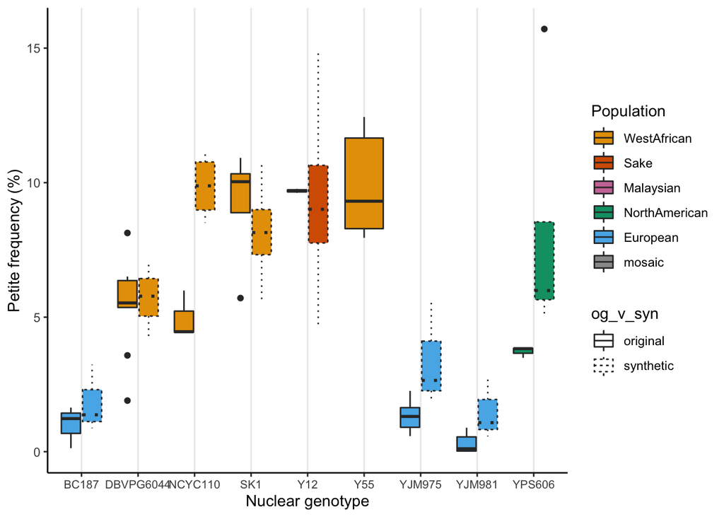

```r
p<-ggplot(data.Y55.OG, aes(x = Nuclear, y = PetFreq, linetype = factor(og_v_syn), fill = factor(NucPop))) +
  geom_boxplot(aes(fill = NucPop))+
  theme_bw()+
  theme(plot.background = element_blank(),panel.grid.major.y = element_blank(), panel.grid.minor.y = element_blank(),panel.border = element_blank() ) +
  theme(axis.line = element_line(color = 'black'))+
  theme(axis.text.x = element_text(size = 8))+
  scale_fill_manual(name = "NucPop", values = cbbPalette2)+
  scale_alpha_manual(name = "og_v_syn", values = c(1, 0.8)) +
  scale_linetype_manual(name = "og_v_syn", values = c("solid", "dotted"))+
  xlab("Nuclear genotype")+ ylab("Petite frequency (%)")+
  theme(legend.position = "right")+
  guides(fill=guide_legend(title="Population"))+
  theme(legend.position = "right")
p
```

#### Fig 2C Stats Is there a difference between the petite frequencies of SK1nuc + SK1mt vs. SK1nuc +Y55mt?

```r
FM.cbind.SK1<-glm(cbind(Petite,Grande)~og_v_syn,data=data2, family=binomial)
anova(FM.cbind.SK1, test="Chisq") #P=0.02 *
```

|  | Df | Deviance | Resid. Df | Resid. Dev | Pr(>Chi) |
| --- | --- | --- | --- | --- | --- |
| NULL | NA | NA | 7 | 70.34366 | NA |
| og_v_syn | 1 | 5.412248 | 6 | 64.93141 | 0.01999595 |

Is there a difference between the petite frequencies of NCYC110nuc + NCYC110mt vs. NCYC110nuc +Y55mt?

```r
FM.cbind.NCYC110<-glm(cbind(Petite,Grande)~og_v_syn,data=data3, family=binomial)
anova(FM.cbind.NCYC110, test="Chisq") #P<0.001 ***
```

|  | Df | Deviance | Resid. Df | Resid. Dev | Pr(>Chi) |
| --- | --- | --- | --- | --- | --- |
| NULL | NA | NA | 6 | 72.228640 | NA |
| og_v_syn | 1 | 63.66924 | 5 | 8.559397 | 1.471644e-15 |

Is there a difference between the petite frequencies of DBVPG6044nuc + DBVPG6044mt vs. DBVPG6044nuc +Y55mt?

```r
FM.cbind.DBVPG6044<-glm(cbind(Petite,Grande)~og_v_syn,data=data4, family=binomial)
anova(FM.cbind.DBVPG6044, test="Chisq") #P = 0.144 ns
```

|  | Df | Deviance | Resid. Df | Resid. Dev | Pr(>Chi) |
| --- | --- | --- | --- | --- | --- |
| NULL | NA | NA | 11 | 75.97847 | NA |
| og_v_syn | 1 | 2.131555 | 10 | 73.84692 | 0.1442943 |

Is there a difference between the petite frequencies of Y12nuc + Y12mt vs. Y12nuc +Y55mt?

```r
FM.cbind.Y12<-glm(cbind(Petite,Grande)~og_v_syn,data=data5, family=binomial)
anova(FM.cbind.Y12, test="Chisq") #P=0.007 **
```

|  | Df | Deviance | Resid. Df | Resid. Dev | Pr(>Chi) |
| --- | --- | --- | --- | --- | --- |
| NULL | NA | NA | 5 | 414.6079 | NA |
| og_v_syn | 1 | 7.344067 | 4 | 407.2639 | 0.006728445 |

Is there a difference between the petite frequencies of YPS606nuc + YPS606mt vs. YPS606nuc +Y55mt?

```r
FM.cbind.YPS606<-glm(cbind(Petite,Grande)~og_v_syn,data=data6, family=binomial)
anova(FM.cbind.YPS606, test="Chisq") #P<0.001 ***
```

|  | Df | Deviance | Resid. Df | Resid. Dev | Pr(>Chi) |
| --- | --- | --- | --- | --- | --- |
| NULL | NA | NA | 6 | 514.6680 | NA |
| og_v_syn | 1 | 246.8212 | 5 | 267.8468 | 1.280777e-55 |

Is there a difference between the petite frequencies of BC187nuc + BC187mt vs. BC187nuc +Y55mt?

```r
FM.cbind.BC187<-glm(cbind(Petite,Grande)~og_v_syn,data=data7, family=binomial)
anova(FM.cbind.BC187, test="Chisq") #P=0.20 ns
```

|  | Df | Deviance | Resid. Df | Resid. Dev | Pr(>Chi) |
| --- | --- | --- | --- | --- | --- |
| NULL | NA | NA | 5 | 32.58876 | NA |
| og_v_syn | 1 | 1.661121 | 4 | 30.92764 | 0.1974521 |

Is there a difference between the petite frequencies of YJM975nuc + YJM975mt vs. YJM975nuc +Y55mt?

```r
FM.cbind.YJM975<-glm(cbind(Petite,Grande)~og_v_syn,data=data8, family=binomial)
anova(FM.cbind.YJM975, test="Chisq") #P<0.001 ***
```

|  | Df | Deviance | Resid. Df | Resid. Dev | Pr(>Chi) |
| --- | --- | --- | --- | --- | --- |
| NULL | NA | NA | 8 | 93.41176 | NA |
| og_v_syn | 1 | 51.41751 | 7 | 41.99425 | 7.466958e-13 |

Is there a difference between the petite frequencies of YJM981nuc + YJM981mt vs. YJM981nuc +Y55mt?

```r
FM.cbind.YJM981<-glm(cbind(Petite,Grande)~og_v_syn,data=data9, family=binomial)
anova(FM.cbind.YJM981, test="Chisq") #P<0.001 ***
```

|  | Df | Deviance | Resid. Df | Resid. Dev | Pr(>Chi) |
| --- | --- | --- | --- | --- | --- |
| NULL | NA | NA | 9 | 113.58531 | NA |
| og_v_syn | 1 | 75.22522 | 8 | 38.36009 | 4.199681e-18 |

### Figure 3

#### Coevolved mitonuclear interactions stabilize mtDNAs.

Analysis of petite frequencies from a 4 nuc x 4 mtDNA mitonuclear collection (16 genotypes). All nuc and mtDNAs have West African origins.

import data

```r
data.4x4<-read.csv("data.4x4mtnWA.csv", header = TRUE, stringsAsFactors = FALSE)
data.4x4$StrainID<-as.factor(data.4x4$StrainID)
data.4x4$Nuclear<-as.factor(data.4x4$Nuclear)
data.4x4$NucPop<-as.factor(data.4x4$NucPop)
data.4x4$Mito<-as.factor(data.4x4$Mito)
data.4x4$MitoPop<-as.factor(data.4x4$MitoPop)
data.4x4$og_v_syn<-as.factor(data.4x4$og_v_syn)
data.4x4$Genotypes<-as.factor(data.4x4$Genotype)
str(data.4x4)
```

```
## 'data.frame':    66 obs. of  13 variables:
##  $ StrainID : Factor w/ 19 levels "21a1","ML11x1UA",..: 1 1 1 1 1 1 3 3 3 15 ...
##  $ Nuclear  : Factor w/ 4 levels "DBVPG6044","NCYC110",..: 1 1 1 1 1 1 1 1 1 1 ...
##  $ NucPop   : Factor w/ 1 level "WestAfrican": 1 1 1 1 1 1 1 1 1 1 ...
##  $ Mito     : Factor w/ 4 levels "DBVPG6044","NCYC110",..: 1 1 1 1 1 1 1 1 1 2 ...
##  $ MitoPop  : Factor w/ 1 level "WestAfrican": 1 1 1 1 1 1 1 1 1 1 ...
##  $ Ploidy   : chr  "Haploid" "Haploid" "Haploid" "Haploid" ...
##  $ og_v_syn : Factor w/ 2 levels "original","synthetic": 1 1 1 1 1 1 1 1 1 2 ...
##  $ Genotype : chr  "MATaura3" "MATaura3" "MATaura3" "MATaura3" ...
##  $ Petite   : int  52 49 70 126 104 146 23 18 77 143 ...
##  $ Grande   : int  892 721 1005 2152 1835 2336 620 928 870 2087 ...
##  $ Total    : int  944 770 1075 2278 1939 2482 643 946 947 2230 ...
##  $ PetFreq  : num  5.51 6.36 6.51 5.53 5.36 5.88 3.58 1.9 8.13 6.41 ...
##  $ Genotypes: Factor w/ 3 levels "MATaura3","MATxura3",..: 1 1 1 1 1 1 3 3 3 2 ...
```

#### Interaction Plot

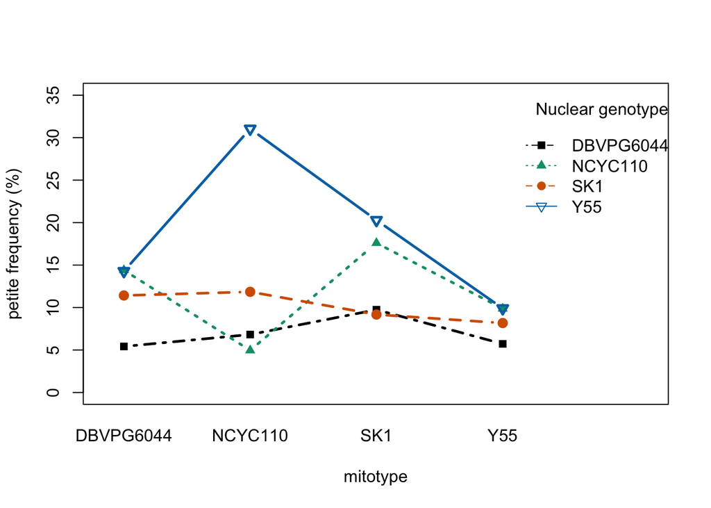

```r
cbbPalette <- c("#000000", "#009E73","#D55E00","#0072B2")

interaction.plot(data.4x4$Mito,data.4x4$Nuclear,data.4x4$PetFreq,
                 lwd=2.5,
                 xlab = "mitotype",ylab = "petite frequency (%)",
                 ylim=c(0,35),trace.label="Nuclear genotype", type = "b", col=c(cbbPalette),
                 pch = c(15,17,19,6), fixed =TRUE)
```

#### Table S5

#### ANOVA Petite frequencies influenced by mitonuclear interactions in a 4x4 mitonuclear genotype panel

Analysis of petite frequencies from a 4 nuc x 4 mtDNA mitonuclear collection (16 genotypes). All nuc and mtDNAs have West African origins.

ANOVA Are there significant nuclear, mtDNA, and mitonuclear interactions in the 4x4 WA collection?

```r
FM.cbind.test<-glm(cbind(Petite,Grande)~Nuclear*Mito,data=data.4x4, family=binomial)
anova(FM.cbind.test, test="Chisq")
```

|  | Df | Deviance | Resid. Df | Resid. Dev | Pr(>Chi) |
| --- | --- | --- | --- | --- | --- |
| NULL | NA | NA | 65 | 5102.7686 | NA |
| Nuclear | 3 | 2993.2064 | 62 | 2109.5622 | 0.000000e+00 |
| Mito | 3 | 576.1124 | 59 | 1533.4498 | 1.519569e-124 |
| Nuclear:Mito | 9 | 1101.3471 | 50 | 432.1027 | 2.375601e-231 |

### Fig S1

#### Strains harboring original mtDNAs have lower petite frequencies than those with synthetic mitonuclear combinations.

Analysis of petite frequencies from a 4 nuc x 4 mtDNA mitonuclear collection (16 genotypes). All nuc and mtDNAs have West African origins. original = strains with their original, coadapted mtDNA synthetic = strains with introduced mtDNAs

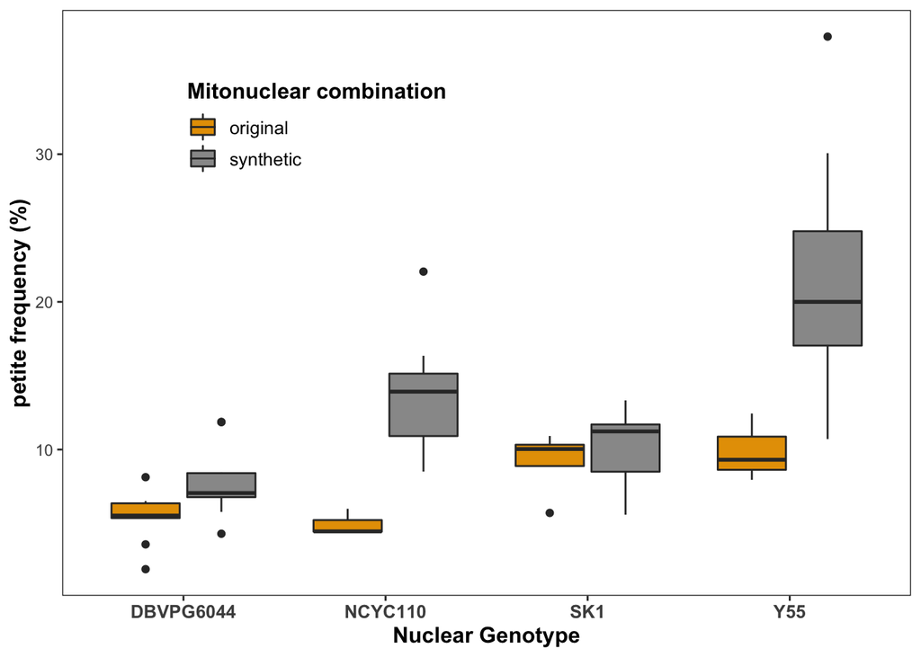

```r
cbbPalette3 <- c("original" = "#E69F00","synthetic" ="#999999")

FigS1<-ggplot(data.4x4,aes(x=Nuclear,y=PetFreq,fill=og_v_syn))+geom_boxplot()+
  theme_bw()+
  theme(plot.background = element_blank(),panel.grid.major = element_blank(), panel.grid.minor = element_blank() ) +
  theme(axis.text.x = element_text(size = 10, face="bold")) +scale_fill_manual(values=cbbPalette3)+
  theme(axis.title = element_text(size = 12, face="bold"))+
  xlab("Nuclear Genotype") + ylab("petite frequency (%)")+
  theme(legend.position = c(0.3,0.8),
  legend.title=element_text(size=12,face="bold"),
  legend.text=element_text(size=10))+
  guides(fill=guide_legend(title="Mitonuclear combination"))
FigS1
```

#### Fig S1 ##### anova comparisons

to calculate P values for each comparison of strains with original or synthetic mtn combinations

subset data

```r
#subset data
data.DB<-subset(data.4x4,data.4x4$Nuclear=="DBVPG6044")
data.NC<-subset(data.4x4,data.4x4$Nuclear=="NCYC110")
data.Y55<-subset(data.4x4,data.4x4$Nuclear=="Y55")
data.SK1<-subset(data.4x4,data.4x4$Nuclear=="SK1")
```

##### FigS1 ANOVA: DBVPG6044 og vs. syn

```r
RM.DB<-glm(cbind(Petite,Grande)~og_v_syn/StrainID,data=data.DB, family=binomial)
anova(RM.DB,test="Chisq")
```

|  | Df | Deviance | Resid. Df | Resid. Dev | Pr(>Chi) |
| --- | --- | --- | --- | --- | --- |
| NULL | NA | NA | 20 | 306.57450 | NA |
| og_v_syn | 1 | 41.52444 | 19 | 265.05006 | 1.164064e-10 |
| og_v_syn:StrainID | 4 | 179.46839 | 15 | 85.58167 | 9.698514e-38 |

##### FigS1 ANOVA: NCYC110 og vs. syn

```r
RM.NC<-glm(cbind(Petite,Grande)~og_v_syn/StrainID,data=data.NC, family=binomial)
anova(RM.NC,test="Chisq")
```

|  | Df | Deviance | Resid. Df | Resid. Dev | Pr(>Chi) |
| --- | --- | --- | --- | --- | --- |
| NULL | NA | NA | 13 | 428.02474 | NA |
| og_v_syn | 1 | 255.0142 | 12 | 173.01052 | 2.095740e-57 |
| og_v_syn:StrainID | 2 | 129.2438 | 10 | 43.76673 | 8.611267e-29 |

##### FigS1 ANOVA: Y55 og vs. syn

```r
RM.Y55<-glm(cbind(Petite,Grande)~og_v_syn/StrainID,data=data.Y55, family=binomial)
anova(RM.Y55,test="Chisq")
```

|  | Df | Deviance | Resid. Df | Resid. Dev | Pr(>Chi) |
| --- | --- | --- | --- | --- | --- |
| NULL | NA | NA | 13 | 1208.3245 | NA |
| og_v_syn | 1 | 411.3335 | 12 | 796.9910 | 1.878664e-91 |
| og_v_syn:StrainID | 2 | 617.7742 | 10 | 179.2168 | 7.112707e-135 |

##### FigS1 ANOVA: SK1 og vs. syn

```r
RM.SK1<-glm(cbind(Petite,Grande)~og_v_syn/StrainID,data=data.SK1, family=binomial)
anova(RM.SK1,test="Chisq")
```

|  | Df | Deviance | Resid. Df | Resid. Dev | Pr(>Chi) |
| --- | --- | --- | --- | --- | --- |
| NULL | NA | NA | 16 | 166.63843 | NA |
| og_v_syn | 1 | 9.229952 | 15 | 157.40848 | 2.380879e-03 |
| og_v_syn:StrainID | 3 | 72.213844 | 12 | 85.19464 | 1.432541e-15 |

### Figure 6

#### Mitonuclear interactions influencing mtDNA stability include HGH1 and YAT1.

import and prepare data

```r
data.ko<-read.csv("parent_v_ko.csv", header = TRUE, stringsAsFactors = FALSE)

#set factors
data.ko$StrainID<-as.factor(data.ko$StrainID)
data.ko$Nuclear<-as.factor(data.ko$Nuclear)
data.ko$Mito<-as.factor(data.ko$Mito)
data.ko$og_v_syn<-as.factor(data.ko$og_v_syn)

#set classes
data.ko$Petite<-as.numeric(data.ko$Petite)
data.ko$Grande<-as.numeric(data.ko$Grande)
data.ko$Total<-as.numeric(data.ko$Total)
```

#### Fig 6A

#### Mitonuclear interactions influencing mtDNA stability include HGH1 and YAT1

examine petite frequency differences in the parental strain BY4741 vs. knockouts

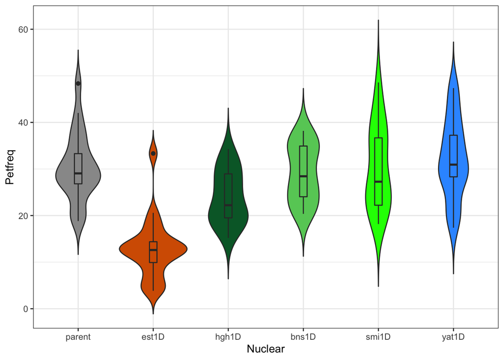

```r
#first reorder dataset
data.ko$Nuclear<-factor(data.ko$Nuclear,levels=c("parent","est1D","hgh1D","bns1D","smi1D","yat1D"))

Fig6A<-ggplot(data.ko, aes(x=Nuclear, y=Petfreq, fill=Nuclear)) +
    geom_violin(trim=FALSE)+theme_bw() +geom_boxplot(width=0.1)+ scale_fill_manual(values=c("#999999", "#D55E00", "#006633","#66CC66","#00FF00","#3399FF"))+theme(legend.position="none")
Fig6A
```

##### Fig 6A Anova comparisons ##### compare parental strain vs. each knockout

##### anova parent vs. est1-delta

```r
     #subset to parent and est1D
      data.e<-subset(data.ko,data.ko$Nuclear=="parent"|data.ko$Nuclear=="est1D")
      str(data.e)
```

```
## 'data.frame':    40 obs. of  12 variables:
##  $ StrainID  : Factor w/ 6 levels "BY4741","YAR035W",..: 6 6 6 6 6 6 6 6 6 6 ...
##  $ Nuclear   : Factor w/ 6 levels "parent","est1D",..: 2 2 2 2 2 2 2 2 2 2 ...
##  $ Mito      : Factor w/ 1 level "BY4741": 1 1 1 1 1 1 1 1 1 1 ...
##  $ og_v_syn  : Factor w/ 1 level "original": 1 1 1 1 1 1 1 1 1 1 ...
##  $ Assay     : chr  "fluccuation" "fluccuation" "fluccuation" "fluccuation" ...
##  $ Plate     : chr  "5A" "5B" "5C" "5D" ...
##  $ Petite    : num  8 8 6 3 12 10 8 1 4 4 ...
##  $ Grande    : num  54 83 45 71 79 45 57 25 24 53 ...
##  $ Total     : num  62 91 51 74 91 55 65 26 28 57 ...
##  $ Petfreq   : num  12.9 8.79 11.76 4.05 13.19 ...
##  $ Pet.mean  : num  12.9 12.9 12.9 12.9 12.9 ...
##  $ Pet.median: num  12.6 12.6 12.6 12.6 12.6 ...
```

```r
      wilcox.test(data.e$Petfreq~data.e$Nuclear)   #W=383, p=1.75e-08***
```

```
##
##  Wilcoxon rank sum exact test
##
## data:  data.e$Petfreq by data.e$Nuclear
## W = 383, p-value = 1.758e-08
## alternative hypothesis: true location shift is not equal to 0
```

```r
      FM.e<-lm(data.e$Petfreq~data.e$Nuclear)
      summary(FM.e)
```

```
##
## Call:
## lm(formula = data.e$Petfreq ~ data.e$Nuclear)
##
## Residuals:
##      Min       1Q   Median       3Q      Max
## -11.6320  -3.6367  -0.6807   1.8520  20.4012
##
## Coefficients:
##                 Estimate Std. Error t value Pr(>|t|)
## (Intercept)       21.694      1.095  19.811  < 2e-16 ***
## data.e$Nuclear1    8.762      1.095   8.001 1.13e-09 ***
## ---
## Signif. codes:  0 '***' 0.001 '**' 0.01 '*' 0.05 '.' 0.1 ' ' 1
##
## s: 6.926 on 38 degrees of freedom
## Multiple R-squared: 0.6275,
## Adjusted R-squared: 0.6177
## F-statistic: 64.02 on 1 and 38 DF,  p-value: 1.135e-09
```

```r
      anova(FM.e) #p=1.135e-09***
```

|  | Df | Sum Sq | Mean Sq | F value | Pr(>F) |
| --- | --- | --- | --- | --- | --- |
| data.e$Nuclear | 1 | 3070.698 | 3070.69766 | 64.02231 | 1.134543e-09 |
| Residuals | 38 | 1822.591 | 47.96293 | NA | NA |

```r
      FM.e2<-glm(cbind(data.e$Petite, data.e$Grande)~data.e$Nuclear, family = binomial)
      anova(FM.e2, test = "Chisq") #p<2.2e-16 ***
```

|  | Df | Deviance | Resid. Df | Resid. Dev | Pr(>Chi) |
| --- | --- | --- | --- | --- | --- |
| NULL | NA | NA | 39 | 213.76868 | NA |
| data.e$Nuclear | 1 | 134.0764 | 38 | 79.69227 | 5.257284e-31 |

##### anova parent vs. hgh1-delta

```r
 #subset to parent and hgh1
      data.h<-subset(data.ko,data.ko$Nuclear=="parent"|data.ko$Nuclear=="hgh1D")
      str(data.h)
```

```
## 'data.frame':    37 obs. of  12 variables:
##  $ StrainID  : Factor w/ 6 levels "BY4741","YAR035W",..: 3 3 3 3 3 3 3 3 3 3 ...
##  $ Nuclear   : Factor w/ 6 levels "parent","est1D",..: 3 3 3 3 3 3 3 3 3 3 ...
##  $ Mito      : Factor w/ 1 level "BY4741": 1 1 1 1 1 1 1 1 1 1 ...
##  $ og_v_syn  : Factor w/ 1 level "original": 1 1 1 1 1 1 1 1 1 1 ...
##  $ Assay     : chr  "fluccuation" "fluccuation" "fluccuation" "fluccuation" ...
##  $ Plate     : chr  "2A" "2B" "2C" "2D" ...
##  $ Petite    : num  30 12 25 15 11 16 5 20 21 13 ...
##  $ Grande    : num  65 67 71 71 44 66 22 47 46 47 ...
##  $ Total     : num  95 79 96 86 55 82 27 67 67 60 ...
##  $ Petfreq   : num  31.6 15.2 26 17.4 20 ...
##  $ Pet.mean  : num  24 24 24 24 24 ...
##  $ Pet.median: num  22.2 22.2 22.2 22.2 22.2 ...
```

```r
      wilcox.test(data.h$Petfreq~data.h$Nuclear)#W=257 p=0.008369** #warning "cannot compute exact p=value with ties"
```

```
##
##  Wilcoxon rank sum test with continuity correction
##
## data:  data.h$Petfreq by data.h$Nuclear
## W = 257, p-value = 0.008369
## alternative hypothesis: true location shift is not equal to 0
```

```r
      FM.h<-lm(data.h$Petfreq~data.h$Nuclear)
      summary(FM.h)
```

```
##
## Call:
## lm(formula = data.h$Petfreq ~ data.h$Nuclear)
##
## Residuals:
##     Min      1Q  Median      3Q     Max
## -11.632  -3.958  -1.609   4.990  17.896
##
## Coefficients:
##                 Estimate Std. Error t value Pr(>|t|)
## (Intercept)       27.207      1.094  24.878  < 2e-16 ***
## data.h$Nuclear1    3.249      1.094   2.971  0.00534 **
## ---
## Signif. codes:  0 '***' 0.001 '**' 0.01 '*' 0.05 '.' 0.1 ' ' 1
##
## s: 6.63 on 35 degrees of freedom
## Multiple R-squared: 0.2014,
## Adjusted R-squared: 0.1786
## F-statistic: 8.826 on 1 and 35 DF,  p-value: 0.005338
```

```r
      anova(FM.h) #p=0.005338**
```

|  | Df | Sum Sq | Mean Sq | F value | Pr(>F) |
| --- | --- | --- | --- | --- | --- |
| data.h$Nuclear | 1 | 387.9989 | 387.9989 | 8.82598 | 0.005337944 |
| Residuals | 35 | 1538.6349 | 43.9610 | NA | NA |

```r
      FM.h2<-glm(cbind(data.h$Petite, data.h$Grande)~data.h$Nuclear, family = binomial)
      anova(FM.h2, test = "Chisq") #p<0.0001307 ***
```

|  | Df | Deviance | Resid. Df | Resid. Dev | Pr(>Chi) |
| --- | --- | --- | --- | --- | --- |
| NULL | NA | NA | 36 | 75.17482 | NA |
| data.h$Nuclear | 1 | 14.63104 | 35 | 60.54378 | 0.0001307432 |

##### anova parent vs. bns1-delta

```r
 #subset to parent and bns1
      data.b<-subset(data.ko,data.ko$Nuclear=="parent"|data.ko$Nuclear=="bns1D")
      str(data.b)
```

```
## 'data.frame':    40 obs. of  12 variables:
##  $ StrainID  : Factor w/ 6 levels "BY4741","YAR035W",..: 5 5 5 5 5 5 5 5 5 5 ...
##  $ Nuclear   : Factor w/ 6 levels "parent","est1D",..: 4 4 4 4 4 4 4 4 4 4 ...
##  $ Mito      : Factor w/ 1 level "BY4741": 1 1 1 1 1 1 1 1 1 1 ...
##  $ og_v_syn  : Factor w/ 1 level "original": 1 1 1 1 1 1 1 1 1 1 ...
##  $ Assay     : chr  "fluccuation" "fluccuation" "fluccuation" "fluccuation" ...
##  $ Plate     : chr  "1A" "1B" "1C" "1D" ...
##  $ Petite    : num  19 23 37 32 18 16 15 15 22 7 ...
##  $ Grande    : num  31 43 67 59 64 50 49 38 49 27 ...
##  $ Total     : num  50 66 104 91 82 66 64 53 71 34 ...
##  $ Petfreq   : num  38 34.8 35.6 35.2 22 ...
##  $ Pet.mean  : num  29.2 29.2 29.2 29.2 29.2 ...
##  $ Pet.median: num  28.4 28.4 28.4 28.4 28.4 ...
```

```r
      wilcox.test(data.b$Petfreq~data.b$Nuclear) #W=217, p=0.6588
```

```
##
##  Wilcoxon rank sum exact test
##
## data:  data.b$Petfreq by data.b$Nuclear
## W = 217, p-value = 0.6588
## alternative hypothesis: true location shift is not equal to 0
```

```r
      FM.b<-lm(data.b$Petfreq~data.b$Nuclear)
      summary(FM.b)
```

```
##
## Call:
## lm(formula = data.b$Petfreq ~ data.b$Nuclear)
##
## Residuals:
##     Min      1Q  Median      3Q     Max
## -11.632  -4.655  -1.022   5.433  17.896
##
## Coefficients:
##                 Estimate Std. Error t value Pr(>|t|)
## (Intercept)      29.8067     1.0669  27.937   <2e-16 ***
## data.b$Nuclear1   0.6489     1.0669   0.608    0.547
## ---
## Signif. codes:  0 '***' 0.001 '**' 0.01 '*' 0.05 '.' 0.1 ' ' 1
##
## s: 6.748 on 38 degrees of freedom
## Multiple R-squared: 0.009639,
## Adjusted R-squared: -0.01642
## F-statistic: 0.3699 on 1 and 38 DF,  p-value: 0.5467
```

```r
      anova(FM.b) #p=0.547 ns
```

|  | Df | Sum Sq | Mean Sq | F value | Pr(>F) |
| --- | --- | --- | --- | --- | --- |
| data.b$Nuclear | 1 | 16.84145 | 16.84145 | 0.3698635 | 0.5466967 |
| Residuals | 38 | 1730.30038 | 45.53422 | NA | NA |

```r
      FM.b2<-glm(cbind(data.b$Petite, data.b$Grande)~data.b$Nuclear, family = binomial)
      anova(FM.b2, test = "Chisq") #p<0.0.7255 ns
```

|  | Df | Deviance | Resid. Df | Resid. Dev | Pr(>Chi) |
| --- | --- | --- | --- | --- | --- |
| NULL | NA | NA | 39 | 62.11951 | NA |
| data.b$Nuclear | 1 | 0.1233089 | 38 | 61.99621 | 0.725473 |

##### anova parent vs. smi1-delta

```r
 #subset to parent and smi1
      data.s<-subset(data.ko,data.ko$Nuclear=="parent"|data.ko$Nuclear=="smi1D")
      str(data.s)
```

```
## 'data.frame':    40 obs. of  12 variables:
##  $ StrainID  : Factor w/ 6 levels "BY4741","YAR035W",..: 1 1 1 1 1 1 1 1 1 1 ...
##  $ Nuclear   : Factor w/ 6 levels "parent","est1D",..: 1 1 1 1 1 1 1 1 1 1 ...
##  $ Mito      : Factor w/ 1 level "BY4741": 1 1 1 1 1 1 1 1 1 1 ...
##  $ og_v_syn  : Factor w/ 1 level "original": 1 1 1 1 1 1 1 1 1 1 ...
##  $ Assay     : chr  "fluccuation" "fluccuation" "fluccuation" "fluccuation" ...
##  $ Plate     : chr  "6A" "6B" "6C" "6D" ...
##  $ Petite    : num  21 24 45 33 24 31 31 12 25 43 ...
##  $ Grande    : num  57 71 111 70 58 53 49 45 100 101 ...
##  $ Total     : num  78 95 156 103 82 84 80 57 125 144 ...
##  $ Petfreq   : num  26.9 25.3 28.8 32 29.3 ...
##  $ Pet.mean  : num  30.5 30.5 30.5 30.5 30.5 ...
##  $ Pet.median: num  29.1 29.1 29.1 29.1 29.1 ...
```

```r
      wilcox.test(data.s$Petfreq~data.s$Nuclear) #W=208, p=0.8392  #warning "cannot compute exact p=value with ties"
```

```
##
##  Wilcoxon rank sum test with continuity correction
##
## data:  data.s$Petfreq by data.s$Nuclear
## W = 208, p-value = 0.8392
## alternative hypothesis: true location shift is not equal to 0
```

```r
      FM.s<-lm(data.s$Petfreq~data.s$Nuclear)
      summary(FM.s)
```

```
##
## Call:
## lm(formula = data.s$Petfreq ~ data.s$Nuclear)
##
## Residuals:
##     Min      1Q  Median      3Q     Max
## -12.247  -5.252  -1.699   5.571  18.143
##
## Coefficients:
##                 Estimate Std. Error t value Pr(>|t|)
## (Intercept)      30.4421     1.2980   23.45   <2e-16 ***
## data.s$Nuclear1   0.0134     1.2980    0.01    0.992
## ---
## Signif. codes:  0 '***' 0.001 '**' 0.01 '*' 0.05 '.' 0.1 ' ' 1
##
## s: 8.209 on 38 degrees of freedom
## Multiple R-squared: 2.805e-06,
## Adjusted R-squared: -0.02631
## F-statistic: 0.0001066 on 1 and 38 DF,  p-value: 0.9918
```

```r
      anova(FM.s) #p=0.9918 ns
```

|  | Df | Sum Sq | Mean Sq | F value | Pr(>F) |
| --- | --- | --- | --- | --- | --- |
| data.s$Nuclear | 1 | 7.182793e-03 | 0.007182793 | 0.0001065773 | 0.9918171 |
| Residuals | 38 | 2.561016e+03 | 67.395167505 | NA | NA |

```r
      FM.s2<-glm(cbind(data.s$Petite, data.s$Grande)~data.s$Nuclear, family = binomial)
      anova(FM.s2, test = "Chisq") #p<0.0.7886 ns
```

|  | Df | Deviance | Resid. Df | Resid. Dev | Pr(>Chi) |
| --- | --- | --- | --- | --- | --- |
| NULL | NA | NA | 39 | 66.32810 | NA |
| data.s$Nuclear | 1 | 0.07186577 | 38 | 66.25624 | 0.7886393 |

##### anova parent vs. yat1-delta

```r
#subset to parent and yat1
      data.y<-subset(data.ko,data.ko$Nuclear=="parent"|data.ko$Nuclear=="yat1D")
      str(data.y)
```

```
## 'data.frame':    40 obs. of  12 variables:
##  $ StrainID  : Factor w/ 6 levels "BY4741","YAR035W",..: 1 1 1 1 1 1 1 1 1 1 ...
##  $ Nuclear   : Factor w/ 6 levels "parent","est1D",..: 1 1 1 1 1 1 1 1 1 1 ...
##  $ Mito      : Factor w/ 1 level "BY4741": 1 1 1 1 1 1 1 1 1 1 ...
##  $ og_v_syn  : Factor w/ 1 level "original": 1 1 1 1 1 1 1 1 1 1 ...
##  $ Assay     : chr  "fluccuation" "fluccuation" "fluccuation" "fluccuation" ...
##  $ Plate     : chr  "6A" "6B" "6C" "6D" ...
##  $ Petite    : num  21 24 45 33 24 31 31 12 25 43 ...
##  $ Grande    : num  57 71 111 70 58 53 49 45 100 101 ...
##  $ Total     : num  78 95 156 103 82 84 80 57 125 144 ...
##  $ Petfreq   : num  26.9 25.3 28.8 32 29.3 ...
##  $ Pet.mean  : num  30.5 30.5 30.5 30.5 30.5 ...
##  $ Pet.median: num  29.1 29.1 29.1 29.1 29.1 ...
```

```r
      wilcox.test(data.y$Petfreq~data.y$Nuclear) #W=172   p=0.4569   #warning "cannot compute exact p=value with ties"
```

```
##
##  Wilcoxon rank sum test with continuity correction
##
## data:  data.y$Petfreq by data.y$Nuclear
## W = 172, p-value = 0.4569
## alternative hypothesis: true location shift is not equal to 0
```

```r
      FM.y<-lm(data.y$Petfreq~data.y$Nuclear)
      summary(FM.y)
```

```
##
## Call:
## lm(formula = data.y$Petfreq ~ data.y$Nuclear)
##
## Residuals:
##     Min      1Q  Median      3Q     Max
## -14.791  -3.867  -1.398   4.764  17.896
##
## Coefficients:
##                 Estimate Std. Error t value Pr(>|t|)
## (Intercept)      31.3189     1.2608  24.841   <2e-16 ***
## data.y$Nuclear1  -0.8634     1.2608  -0.685    0.498
## ---
## Signif. codes:  0 '***' 0.001 '**' 0.01 '*' 0.05 '.' 0.1 ' ' 1
##
## s: 7.974 on 38 degrees of freedom
## Multiple R-squared: 0.01219,
## Adjusted R-squared: -0.0138
## F-statistic: 0.469 on 1 and 38 DF,  p-value: 0.4976
```

```r
      anova(FM.y) #p=0.4978
```

|  | Df | Sum Sq | Mean Sq | F value | Pr(>F) |
| --- | --- | --- | --- | --- | --- |
| data.y$Nuclear | 1 | 29.81682 | 29.81682 | 0.4689658 | 0.4976193 |
| Residuals | 38 | 2416.03760 | 63.57994 | NA | NA |

```r
      FM.y2<-glm(cbind(data.y$Petite, data.y$Grande)~data.y$Nuclear, family = binomial)
      anova(FM.y2, test = "Chisq") #p<0.0.3097 ns
```

|  | Df | Deviance | Resid. Df | Resid. Dev | Pr(>Chi) |
| --- | --- | --- | --- | --- | --- |
| NULL | NA | NA | 39 | 86.63973 | NA |
| data.y$Nuclear | 1 | 1.031931 | 38 | 85.60780 | 0.3097056 |

#### Fig 6B

#### Petite frequencies of hgh1-delta and yat1-delta strains depend on mitotype.

import data

```r
data.ko.mtn<-read.csv("data.ko.phy.mtn.csv", header = TRUE, stringsAsFactors = FALSE)

data.ko.mtn$Mito<-as.factor(data.ko.mtn$Mito)
     data.ko.mtn$Nuclear<-as.factor(data.ko.mtn$Nuclear)
      data.ko.mtn$StrainID<-as.factor(data.ko.mtn$StrainID)
      data.ko.mtn$og_v_syn<-as.factor(data.ko.mtn$og_v_syn)
      data.ko.mtn$Assay<-as.factor(data.ko.mtn$Assay)
      data.ko.mtn$Plate<-as.factor(data.ko.mtn$Plate)
```

interaction plot

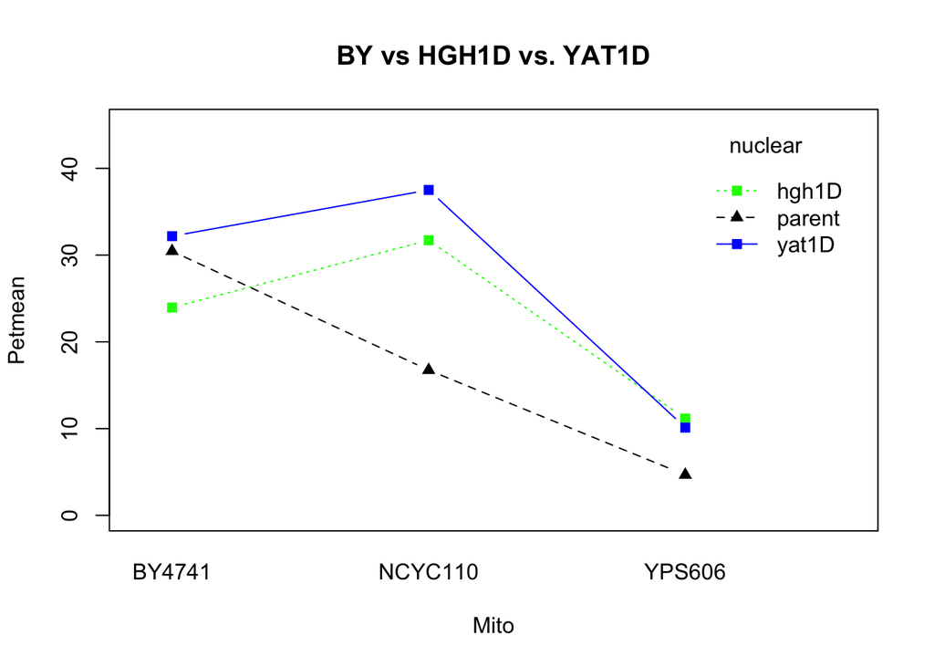

```r
interaction.plot(data.ko.mtn$Mito,data.ko.mtn$Nuclear,data.ko.mtn$Pet.mean,
                             xlab = "Mito",ylab = "Petmean",
                             main = "BY vs HGH1D vs. YAT1D",
                             ylim=c(0,45),trace.label="nuclear", type = "b", col=c("green","black","blue"),
                             pch = c(15,17), fixed =TRUE)
```

##### Fig 6B and Table S10 Statistics ##### Table S10 anovas ###### Table S10 anova on full dataset

```r
      FM.ko.mtn.cbind<-glm(cbind(data.ko.mtn$Petite, data.ko.mtn$Grande)~data.ko.mtn$Nuclear*data.ko.mtn$Mito, family = binomial)
      anova(FM.ko.mtn.cbind, test = "Chisq")
```

|  | Df | Deviance | Resid. Df | Resid. Dev | Pr(>Chi) |
| --- | --- | --- | --- | --- | --- |
| NULL | NA | NA | 174 | 1185.6790 | NA |
| data.ko.mtn$Nuclear | 2 | 78.28662 | 172 | 1107.3924 | 1.000635e-17 |
| data.ko.mtn$Mito | 2 | 714.08607 | 170 | 393.3063 | 8.673224e-156 |
| data.ko.mtn$Nuclear:data.ko.mtn$Mito | 4 | 108.76528 | 166 | 284.5411 | 1.334421e-22 |

###### anova: pairwise comparisons

###### subset data for each pairwise test

```r
data.ph<-subset(data.ko.mtn,data.ko.mtn$Nuclear=="parent"|data.ko.mtn$Nuclear=="hgh1D")
data.phPN<-subset(data.ph,data.ph$Mito=="BY4741"|data.ph$Mito=="NCYC110")
data.phPY<-subset(data.ph,data.ph$Mito=="BY4741"|data.ph$Mito=="YPS606")

data.py<-subset(data.ko.mtn,data.ko.mtn$Nuclear=="parent"|data.ko.mtn$Nuclear=="yat1D")
data.pyPN<-subset(data.py,data.py$Mito=="BY4741"|data.py$Mito=="NCYC110")
data.pyPY<-subset(data.py,data.py$Mito=="BY4741"|data.py$Mito=="YPS606")
```

###### Table S10

###### Parental vs. hgh1∆

###### mtDNA comparison: BY4741 vs NCYC110

```r
FM.phPN.cbind<-glm(cbind(data.phPN$Petite, data.phPN$Grande)~data.phPN$Nuclear*data.phPN$Mito, family = binomial)
      anova(FM.phPN.cbind, test = "Chisq")
```

|  | Df | Deviance | Resid. Df | Resid. Dev | Pr(>Chi) |
| --- | --- | --- | --- | --- | --- |
| NULL | NA | NA | 76 | 223.3770 | NA |
| data.phPN$Nuclear | 1 | 7.717848 | 75 | 215.6592 | 5.467754e-03 |
| data.phPN$Mito | 1 | 3.947839 | 74 | 211.7113 | 4.693161e-02 |
| data.phPN$Nuclear:data.phPN$Mito | 1 | 82.554025 | 73 | 129.1573 | 1.028210e-19 |

###### Table S10

###### Parental vs. hgh1∆

###### mtDNA comparison: BY4741 vs YPS606

```r
FM.phPY.cbind<-glm(cbind(data.phPY$Petite, data.phPY$Grande)~data.phPY$Nuclear*data.phPY$Mito, family = binomial)
      anova(FM.phPY.cbind, test = "Chisq")
```

|  | Df | Deviance | Resid. Df | Resid. Dev | Pr(>Chi) |
| --- | --- | --- | --- | --- | --- |
| NULL | NA | NA | 75 | 534.9091 | NA |
| data.phPY$Nuclear | 1 | 11.30809 | 74 | 523.6011 | 7.717004e-04 |
| data.phPY$Mito | 1 | 373.45541 | 73 | 150.1456 | 3.310199e-83 |
| data.phPY$Nuclear:data.phPY$Mito | 1 | 34.10168 | 72 | 116.0440 | 5.230603e-09 |

###### Table S10

###### Parental vs. yat1∆

###### mtDNA comparison: BY4741 vs NCYC110

```r
FM.pyPN.cbind<-glm(cbind(data.pyPN$Petite, data.pyPN$Grande)~data.pyPN$Nuclear*data.pyPN$Mito, family = binomial)
      anova(FM.pyPN.cbind, test = "Chisq")
```

|  | Df | Deviance | Resid. Df | Resid. Dev | Pr(>Chi) |
| --- | --- | --- | --- | --- | --- |
| NULL | NA | NA | 79 | 281.3666 | NA |
| data.pyPN$Nuclear | 1 | 58.943027 | 78 | 222.4236 | 1.623040e-14 |
| data.pyPN$Mito | 1 | 6.798576 | 77 | 215.6250 | 9.123061e-03 |
| data.pyPN$Nuclear:data.pyPN$Mito | 1 | 67.642871 | 76 | 147.9822 | 1.959600e-16 |

###### Table S10

###### Parental vs. yat1∆

###### mtDNA comparison: BY4741 vs YPS606

```r
FM.pyPY.cbind<-glm(cbind(data.pyPY$Petite, data.pyPY$Grande)~data.pyPY$Nuclear*data.pyPY$Mito, family = binomial)
      anova(FM.pyPY.cbind, test = "Chisq")
```

|  | Df | Deviance | Resid. Df | Resid. Dev | Pr(>Chi) |
| --- | --- | --- | --- | --- | --- |
| NULL | NA | NA | 78 | 667.5406 | NA |
| data.pyPY$Nuclear | 1 | 3.159081 | 77 | 664.3815 | 7.550568e-02 |
| data.pyPY$Mito | 1 | 501.793131 | 76 | 162.5884 | 3.870995e-111 |
| data.pyPY$Nuclear:data.pyPY$Mito | 1 | 15.498017 | 75 | 147.0904 | 8.259185e-05 |

#### Mitonuclear effects of bns1-delta, smi1-delta and hgh1-delta on Petite frequencies

```r
#import data
data.ko.mtn.bhg<-read.csv("data.ko.mtn.rollerassays_bns1smi1hgh1.csv", header = TRUE, stringsAsFactors = FALSE)
data.ko.mtn.bhg$Mitotype<-as.factor(data.ko.mtn.bhg$Mitotype)
data.ko.mtn.bhg$GeneKO<-as.factor(data.ko.mtn.bhg$GeneKO)
#set classes
data.ko.mtn.bhg$Petite<-as.integer(data.ko.mtn.bhg$Petite)
data.ko.mtn.bhg$Grande<-as.integer(data.ko.mtn.bhg$Grande)
data.ko.mtn.bhg$Total<-as.integer(data.ko.mtn.bhg$Total)
```

interaction plot

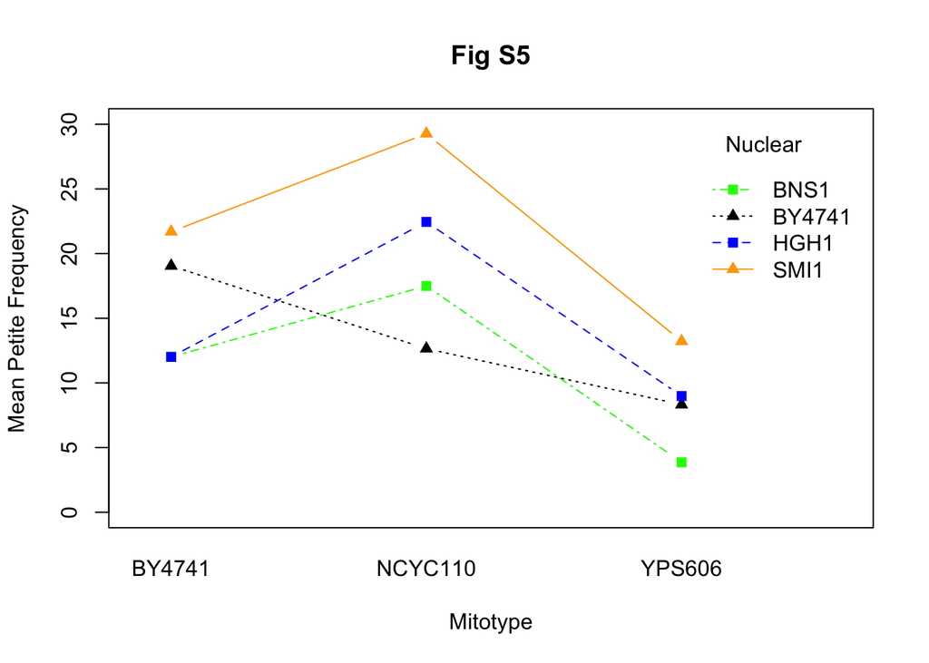

```r
interaction.plot(data.ko.mtn.bhg$Mitotype ,data.ko.mtn.bhg$GeneKO ,data.ko.mtn.bhg$Pet.Mean,
                 xlab = "Mitotype",ylab = "Mean Petite Frequency",
                 main = "Fig S5",
                 ylim=c(0,30),trace.label="Nuclear", type = "b", col=c("green","black","blue","orange"),
                 pch = c(15,17), fixed =TRUE)
```

##### Table S11 stats

```r
      FM.ko.mtn.bhg.cbind<-glm(cbind(data.ko.mtn.bhg$Petite, data.ko.mtn.bhg$Grande)~data.ko.mtn.bhg$GeneKO*data.ko.mtn.bhg$Mitotype, family = binomial)
      anova(FM.ko.mtn.bhg.cbind, test = "Chisq")
```

|  | Df | Deviance | Resid. Df | Resid. Dev | Pr(>Chi) |
| --- | --- | --- | --- | --- | --- |
| NULL | NA | NA | 111 | 4099.894 | NA |
| data.ko.mtn.bhg$GeneKO | 3 | 570.7713 | 108 | 3529.123 | 2.185349e-123 |
| data.ko.mtn.bhg$Mitotype | 2 | 1579.2405 | 106 | 1949.883 | 0.000000e+00 |
| data.ko.mtn.bhg$GeneKO:data.ko.mtn.bhg$Mitotype | 6 | 597.5263 | 100 | 1352.356 | 7.968022e-126 |

## Expression Data

import data

```r
data.rtpcr<-read.table("Relative Expression.txt")

data.rtpcr$Can_Hap<-as.factor(data.rtpcr$Can_Hap)
data.rtpcr$Mitotype<-as.factor(data.rtpcr$Mitotype)
data.rtpcr$MIP1_Hap<-as.factor(data.rtpcr$MIP1_Hap)
```

###Fig S6 ### Does expression correlate with petite frequency? ##### Plot

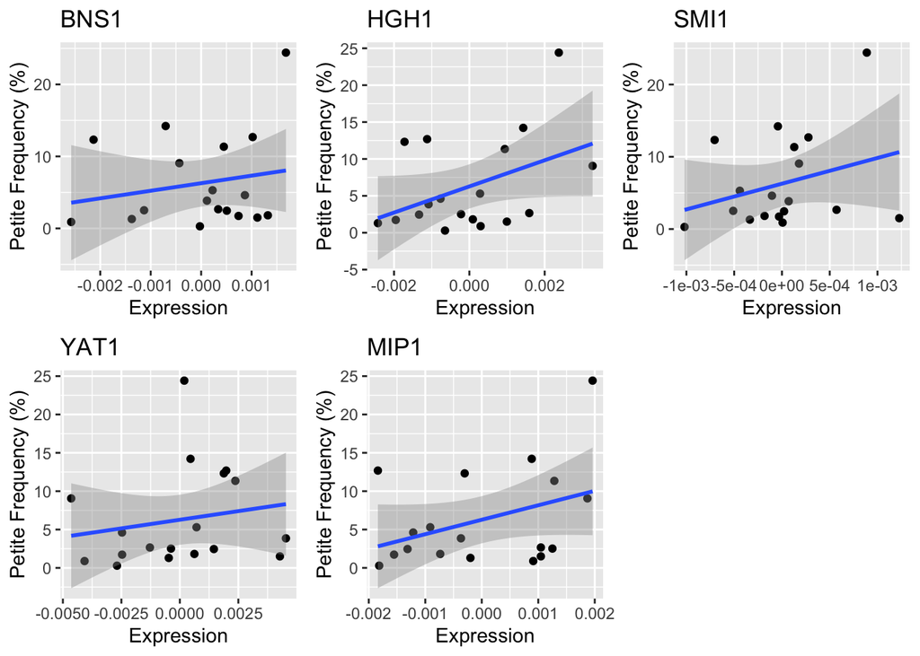

```r
require(ggplot2)
library(ggplot2)
# Gene Expression compared to petite frequency. MPI1 = ALL
BNS1.pf <- ggplot(data.rtpcr, aes(x = BNS1_res, y = Pet_Freq)) + geom_point() + geom_smooth(method = lm) + ggtitle("BNS1") + xlab("Expression") + ylab("Petite Frequency (%)")
HGH1.pf <- ggplot(data.rtpcr, aes(x = HGH1_res, y = Pet_Freq)) + geom_point() + geom_smooth(method = lm) + ggtitle("HGH1") + xlab("Expression") + ylab("Petite Frequency (%)")
SMI1.pf <- ggplot(data.rtpcr, aes(x = SMI1_res, y = Pet_Freq)) + geom_point() + geom_smooth(method = lm) + ggtitle("SMI1") + xlab("Expression") + ylab("Petite Frequency (%)")
YAT1.pf <- ggplot(data.rtpcr, aes(x = YAT1_res, y = Pet_Freq)) + geom_point() + geom_smooth(method = lm) + ggtitle("YAT1") + xlab("Expression") + ylab("Petite Frequency (%)")
MIP1.pf <- ggplot(data.rtpcr, aes(x = MIP1_res, y = Pet_Freq)) + geom_point() + geom_smooth(method = lm) + ggtitle("MIP1") + xlab("Expression") + ylab("Petite Frequency (%)")

# combine plots to a single grid
require("gridExtra")
grid.pf <- grid.arrange(BNS1.pf, HGH1.pf, SMI1.pf, YAT1.pf, MIP1.pf, nrow = 2, ncol = 3)
```

```r
###
```

##### stats for Fig S6

```r
# Does expression of MIP1 correlate with petite frequency??

# linear model of correlation between expression and petite frequency in MIP1
lm.mip.pfr <- lm(data.rtpcr$Pet_Freq ~ data.rtpcr$MIP1_res)
anova.mip.pfr <- anova(lm.mip.pfr)
anova.mip.pfr
```

|  | Df | Sum Sq | Mean Sq | F value | Pr(>F) |
| --- | --- | --- | --- | --- | --- |
| data.rtpcr$MIP1_res | 1 | 100.5715 | 100.57155 | 2.651311 | 0.1229927 |
| Residuals | 16 | 606.9241 | 37.93276 | NA | NA |

```r
# p = 0.1229927, no correlation
summary(lm.mip.pfr) #R2=0.1422,
```

```
##
## Call:
## lm(formula = data.rtpcr$Pet_Freq ~ data.rtpcr$MIP1_res)
##
## Residuals:
##    Min     1Q Median     3Q    Max
## -7.104 -4.217 -1.482  2.172 14.439
##
## Coefficients:
##                     Estimate Std. Error t value Pr(>|t|)
## (Intercept)            6.276      1.452   4.323 0.000525 ***
## data.rtpcr$MIP1_res 1885.434   1157.926   1.628 0.122993
## ---
## Signif. codes:  0 '***' 0.001 '**' 0.01 '*' 0.05 '.' 0.1 ' ' 1
##
## s: 6.159 on 16 degrees of freedom
## Multiple R-squared: 0.1422,
## Adjusted R-squared: 0.08854
## F-statistic: 2.651 on 1 and 16 DF,  p-value: 0.123
```

```r
cor.test.mip.pfr<-cor.test(data.rtpcr$Pet_Freq,data.rtpcr$MIP1_res)
cor.test.mip.pfr #cor=r=0.0.3770298
```

```
##
##  Pearson's product-moment correlation
##
## data:  data.rtpcr$Pet_Freq and data.rtpcr$MIP1_res
## t = 1.6283, df = 16, p-value = 0.123
## alternative hypothesis: true correlation is not equal to 0
## 95 percent confidence interval:
##  -0.1090326  0.7175873
## sample estimates:
##       cor
## 0.3770298
```

```r
cor.test.mip.pfr$p.value #p=0.1229927
```

```
## [1] 0.1229927
```

```r
# Does expression of BNS1 correlate with petite frequency?
lm.bns.pfr <- lm(data.rtpcr$Pet_Freq ~ data.rtpcr$BNS1_res)
anova.bns.pfr <- anova(lm.bns.pfr)
anova.bns.pfr
```

|  | Df | Sum Sq | Mean Sq | F value | Pr(>F) |
| --- | --- | --- | --- | --- | --- |
| data.rtpcr$BNS1_res | 1 | 26.29795 | 26.29795 | 0.6176874 | 0.4433923 |
| Residuals | 16 | 681.19771 | 42.57486 | NA | NA |

```r
# p = 0.4434, no correlation
summary(lm.bns.pfr) #R2=0.03717
```

```
##
## Call:
## lm(formula = data.rtpcr$Pet_Freq ~ data.rtpcr$BNS1_res)
##
## Residuals:
##    Min     1Q Median     3Q    Max
## -5.960 -4.257 -2.573  4.258 16.373
##
## Coefficients:
##                     Estimate Std. Error t value Pr(>|t|)
## (Intercept)            6.276      1.538   4.081 0.000871 ***
## data.rtpcr$BNS1_res 1050.590   1336.746   0.786 0.443392
## ---
## Signif. codes:  0 '***' 0.001 '**' 0.01 '*' 0.05 '.' 0.1 ' ' 1
##
## s: 6.525 on 16 degrees of freedom
## Multiple R-squared: 0.03717,
## Adjusted R-squared: -0.02301
## F-statistic: 0.6177 on 1 and 16 DF,  p-value: 0.4434
```

```r
cor.test.bns.pfr<-cor.test(data.rtpcr$Pet_Freq,data.rtpcr$BNS1_res)
cor.test.bns.pfr #cor=r=0.1927965
```

```
##
##  Pearson's product-moment correlation
##
## data:  data.rtpcr$Pet_Freq and data.rtpcr$BNS1_res
## t = 0.78593, df = 16, p-value = 0.4434
## alternative hypothesis: true correlation is not equal to 0
## 95 percent confidence interval:
##  -0.3011834  0.6051926
## sample estimates:
##       cor
## 0.1927965
```

```r
cor.test.bns.pfr$p.value #p=0.4433923
```

```
## [1] 0.4433923
```

```r
#Does expression of HGH1 correlate with petite frequency?
lm.hgh.pfr <- lm(data.rtpcr$Pet_Freq ~ data.rtpcr$HGH1_res)
anova.hgh.pfr <- anova(lm.hgh.pfr)
anova.hgh.pfr
```

|  | Df | Sum Sq | Mean Sq | F value | Pr(>F) |
| --- | --- | --- | --- | --- | --- |
| data.rtpcr$HGH1_res | 1 | 128.7348 | 128.73477 | 3.558907 | 0.07751052 |
| Residuals | 16 | 578.7609 | 36.17256 | NA | NA |

```r
# p = 0.07751, no correlation :/
summary(lm.hgh.pfr) #R2=0.182,
```

```
##
## Call:
## lm(formula = data.rtpcr$Pet_Freq ~ data.rtpcr$HGH1_res)
##
## Residuals:
##    Min     1Q Median     3Q    Max
## -6.540 -4.309 -1.267  2.474 13.925
##
## Coefficients:
##                     Estimate Std. Error t value Pr(>|t|)
## (Intercept)            6.276      1.418   4.427 0.000423 ***
## data.rtpcr$HGH1_res 1773.321    940.002   1.887 0.077511 .
## ---
## Signif. codes:  0 '***' 0.001 '**' 0.01 '*' 0.05 '.' 0.1 ' ' 1
##
## s: 6.014 on 16 degrees of freedom
## Multiple R-squared: 0.182,
## Adjusted R-squared: 0.1308
## F-statistic: 3.559 on 1 and 16 DF,  p-value: 0.07751
```

```r
cor.test.hgh.pfr<-cor.test(data.rtpcr$Pet_Freq,data.rtpcr$HGH1_res)
cor.test.hgh.pfr #cor=r=0.4265
```

```
##
##  Pearson's product-moment correlation
##
## data:  data.rtpcr$Pet_Freq and data.rtpcr$HGH1_res
## t = 1.8865, df = 16, p-value = 0.07751
## alternative hypothesis: true correlation is not equal to 0
## 95 percent confidence interval:
##  -0.05032692  0.74505714
## sample estimates:
##       cor
## 0.4265658
```

```r
cor.test.hgh.pfr$p.value #p=0.0775
```

```
## [1] 0.07751052
```

```r
#Does expression of SMI1 correlate with petite frequency?
lm.smi.pfr <- lm(data.rtpcr$Pet_Freq ~ data.rtpcr$SMI1_res)
anova.smi.pfr <- anova(lm.smi.pfr)
anova.smi.pfr
```

|  | Df | Sum Sq | Mean Sq | F value | Pr(>F) |
| --- | --- | --- | --- | --- | --- |
| data.rtpcr$SMI1_res | 1 | 62.19487 | 62.19487 | 1.542099 | 0.2322017 |
| Residuals | 16 | 645.30080 | 40.33130 | NA | NA |

```r
# p = 0.2322, no correlation
summary(lm.smi.pfr) #R2=0.08791
```

```
##
## Call:
## lm(formula = data.rtpcr$Pet_Freq ~ data.rtpcr$SMI1_res)
##
## Residuals:
##    Min     1Q Median     3Q    Max
## -9.147 -3.876 -2.149  3.996 14.976
##
## Coefficients:
##                     Estimate Std. Error t value Pr(>|t|)
## (Intercept)            6.276      1.497   4.193 0.000689 ***
## data.rtpcr$SMI1_res 3561.285   2867.811   1.242 0.232202
## ---
## Signif. codes:  0 '***' 0.001 '**' 0.01 '*' 0.05 '.' 0.1 ' ' 1
##
## s: 6.351 on 16 degrees of freedom
## Multiple R-squared: 0.08791,
## Adjusted R-squared: 0.0309
## F-statistic: 1.542 on 1 and 16 DF,  p-value: 0.2322
```

```r
cor.test.smi.pfr<-cor.test(data.rtpcr$Pet_Freq,data.rtpcr$SMI1_res)
cor.test.smi.pfr #cor=r=0.2964936
```

```
##
##  Pearson's product-moment correlation
##
## data:  data.rtpcr$Pet_Freq and data.rtpcr$SMI1_res
## t = 1.2418, df = 16, p-value = 0.2322
## alternative hypothesis: true correlation is not equal to 0
## 95 percent confidence interval:
##  -0.1977498  0.6705443
## sample estimates:
##       cor
## 0.2964936
```

```r
cor.test.smi.pfr$p.value #p=0.2322017
```

```
## [1] 0.2322017
```

```r
#Does expression of YAT1 correlate with petite frequency?
lm.yat.pfr <- lm(data.rtpcr$Pet_Freq ~ data.rtpcr$YAT1_res)
anova.yat.pfr <- anova(lm.yat.pfr)
anova.yat.pfr
```

|  | Df | Sum Sq | Mean Sq | F value | Pr(>F) |
| --- | --- | --- | --- | --- | --- |
| data.rtpcr$YAT1_res | 1 | 23.18008 | 23.18008 | 0.541974 | 0.4722721 |
| Residuals | 16 | 684.31559 | 42.76972 | NA | NA |

```r
# p = 0.4723, no correlation
summary(lm.yat.pfr) #R2=0.03276
```

```
##
## Call:
## lm(formula = data.rtpcr$Pet_Freq ~ data.rtpcr$YAT1_res)
##
## Residuals:
##    Min     1Q Median     3Q    Max
## -6.696 -4.470 -3.240  4.654 18.053
##
## Coefficients:
##                     Estimate Std. Error t value Pr(>|t|)
## (Intercept)            6.276      1.541   4.072 0.000888 ***
## data.rtpcr$YAT1_res  449.326    610.341   0.736 0.472272
## ---
## Signif. codes:  0 '***' 0.001 '**' 0.01 '*' 0.05 '.' 0.1 ' ' 1
##
## s: 6.54 on 16 degrees of freedom
## Multiple R-squared: 0.03276,
## Adjusted R-squared: -0.02769
## F-statistic: 0.542 on 1 and 16 DF,  p-value: 0.4723
```

```r
cor.test.yat.pfr<-cor.test(data.rtpcr$Pet_Freq,data.rtpcr$YAT1_res)
cor.test.yat.pfr #cor=r=0.0.181
```

```
##
##  Pearson's product-moment correlation
##
## data:  data.rtpcr$Pet_Freq and data.rtpcr$YAT1_res
## t = 0.73619, df = 16, p-value = 0.4723
## alternative hypothesis: true correlation is not equal to 0
## 95 percent confidence interval:
##  -0.3122503  0.5973934
## sample estimates:
##       cor
## 0.1810071
```

```r
cor.test.yat.pfr$p.value #p=0.47227
```

```
## [1] 0.4722721
```

### Fig S7

#### Expression based on mitonuclear candidate haplotypes or MIP1 haplotype

##### plot

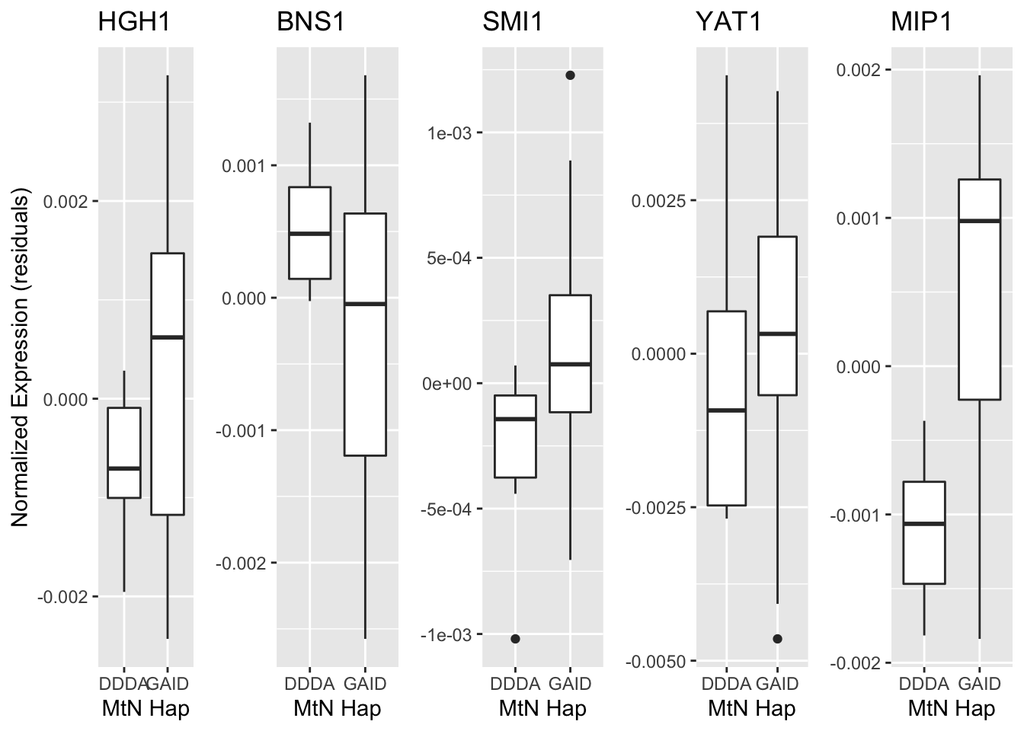

```r
#Fig S7
require(ggplot2)
library(ggplot2)

# Gene Expression in Candidate Haplotypes (DDDA, GAID)
BNS1.Can <- ggplot(data.rtpcr, aes(x = Can_Hap, y = BNS1_res)) + geom_boxplot() + ggtitle("BNS1") + xlab("MtN Hap") + ylab(NULL)
HGH1.Can <- ggplot(data.rtpcr, aes(x = Can_Hap, y = HGH1_res)) + geom_boxplot() + ggtitle("HGH1") + xlab("MtN Hap") + ylab("Normalized Expression (residuals)")
SMI1.Can <- ggplot(data.rtpcr, aes(x = Can_Hap, y = SMI1_res)) + geom_boxplot() + ggtitle("SMI1") + xlab("MtN Hap") + ylab(NULL)
YAT1.Can <- ggplot(data.rtpcr, aes(x = Can_Hap, y = YAT1_res)) + geom_boxplot() + ggtitle("YAT1") + xlab("MtN Hap") + ylab(NULL)
MIP1.Can <- ggplot(data.rtpcr, aes(x = Can_Hap, y = MIP1_res)) + geom_boxplot() + ggtitle("MIP1") + xlab("MtN Hap") + ylab(NULL)


# Gene Expression in MIP1 Haplotypes (GGC, TAT)
BNS1.MIP1_Hap <- ggplot(data.rtpcr, aes(x = MIP1_Hap, y = BNS1_res)) + geom_boxplot() + ggtitle("BNS1") + xlab("MIP1 Hap") + ylab(NULL)
HGH1.MIP1_Hap <- ggplot(data.rtpcr, aes(x = MIP1_Hap, y = HGH1_res)) + geom_boxplot() + ggtitle("HGH1") + xlab("MIP1 Hap") + ylab("Normalized Expression (residuals)")
SMI1.MIP1_Hap <- ggplot(data.rtpcr, aes(x = MIP1_Hap, y = SMI1_res)) + geom_boxplot() + ggtitle("SMI1") + xlab("MIP1 Hap") + ylab(NULL)
YAT1.MIP1_Hap <- ggplot(data.rtpcr, aes(x = MIP1_Hap, y = YAT1_res)) + geom_boxplot() + ggtitle("YAT1") + xlab("MIP1 Hap") + ylab(NULL)
MIP1.MIP1_Hap <- ggplot(data.rtpcr, aes(x = MIP1_Hap, y = MIP1_res)) + geom_boxplot() + ggtitle("MIP1") + xlab("MIP1 Hap") + ylab(NULL)

require("gridExtra")
grid.CAN<-grid.arrange(HGH1.Can, BNS1.Can, SMI1.Can, YAT1.Can, MIP1.Can, nrow = 1, ncol = 5)
```

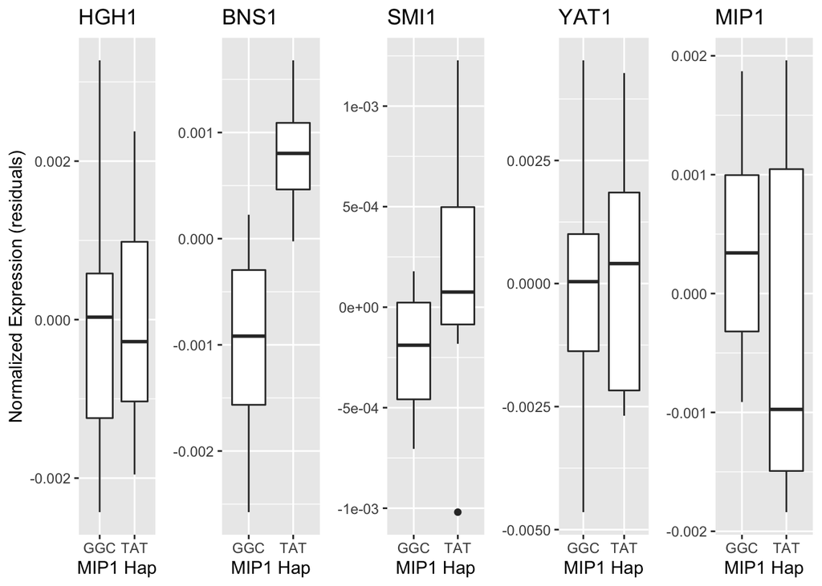

```r
grid.MIP1.hap <- grid.arrange(HGH1.MIP1_Hap,BNS1.MIP1_Hap,SMI1.MIP1_Hap,YAT1.MIP1_Hap, MIP1.MIP1_Hap, nrow = 1, ncol = 5)
```

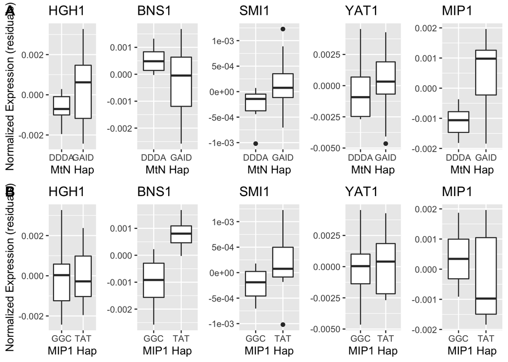

```r
plotcombined<-ggarrange(grid.CAN,grid.MIP1.hap,
                         labels = c("A", "B"),
                         ncol = 1, nrow = 2, align = "h")
plotcombined
```

### Table S12

##### P values from these analyses shown on Fig S7

```r
# Is expression of MIP1 influenced by it's haplotype, the haplotype of the mitonuclear candidates, mitotype or any interaction?
lm.exp.mip <- lm(data.rtpcr$MIP1_res ~ (data.rtpcr$Can_Hap * data.rtpcr$Mitotype * data.rtpcr$MIP1_Hap))
anova.exp.mip <- anova(lm.exp.mip)
anova.exp.mip
```

|  | Df | Sum Sq | Mean Sq | F value | Pr(>F) |
| --- | --- | --- | --- | --- | --- |
| data.rtpcr$Can_Hap | 1 | 1.088608e-05 | 1.088608e-05 | 6.76430887 | 0.02645386 |
| data.rtpcr$Mitotype | 1 | 3.461396e-08 | 3.461396e-08 | 0.02150815 | 0.88631754 |
| data.rtpcr$MIP1_Hap | 1 | 9.531801e-07 | 9.531801e-07 | 0.59227963 | 0.45933171 |
| data.rtpcr$Can_Hap:data.rtpcr$Mitotype | 1 | 8.763698e-08 | 8.763698e-08 | 0.05445518 | 0.82019213 |
| data.rtpcr$Can_Hap:data.rtpcr$MIP1_Hap | 1 | 9.323937e-08 | 9.323937e-08 | 0.05793635 | 0.81465081 |
| data.rtpcr$Mitotype:data.rtpcr$MIP1_Hap | 1 | 5.842142e-08 | 5.842142e-08 | 0.03630144 | 0.85270670 |
| data.rtpcr$Can_Hap:data.rtpcr$Mitotype:data.rtpcr$MIP1_Hap | 1 | 8.468457e-08 | 8.468457e-08 | 0.05262064 | 0.82318805 |
| Residuals | 10 | 1.609341e-05 | 1.609341e-06 | NA | NA |

```r
# Is expression of BNS11 influenced by it's haplotype, the haplotype of the mitonuclear candidates, mitotype or any interaction?

lm.exp.bns <- lm(data.rtpcr$BNS1_res ~ (data.rtpcr$Can_Hap * data.rtpcr$Mitotype * data.rtpcr$MIP1_Hap))
anova.exp.bns <- anova(lm.exp.bns)
anova.exp.bns
```

|  | Df | Sum Sq | Mean Sq | F value | Pr(>F) |
| --- | --- | --- | --- | --- | --- |
| data.rtpcr$Can_Hap | 1 | 2.629909e-06 | 2.629909e-06 | 5.396904305 | 0.0425457598 |
| data.rtpcr$Mitotype | 1 | 4.366153e-07 | 4.366153e-07 | 0.895989570 | 0.3661703967 |
| data.rtpcr$MIP1_Hap | 1 | 1.288001e-05 | 1.288001e-05 | 26.431393845 | 0.0004370318 |
| data.rtpcr$Can_Hap:data.rtpcr$Mitotype | 1 | 3.214426e-07 | 3.214426e-07 | 0.659640598 | 0.4355943771 |
| data.rtpcr$Can_Hap:data.rtpcr$MIP1_Hap | 1 | 2.629368e-06 | 2.629368e-06 | 5.395793526 | 0.0425630919 |
| data.rtpcr$Mitotype:data.rtpcr$MIP1_Hap | 1 | 5.510567e-08 | 5.510567e-08 | 0.113083758 | 0.7436100855 |
| data.rtpcr$Can_Hap:data.rtpcr$Mitotype:data.rtpcr$MIP1_Hap | 1 | 7.912425e-10 | 7.912425e-10 | 0.001623729 | 0.9686506810 |
| Residuals | 10 | 4.872996e-06 | 4.872996e-07 | NA | NA |

```r
# Is expression of HGH11 influenced by it's haplotype, the haplotype of the mitonuclear candidates, mitotype or any interaction?

lm.exp.hgh <- lm(data.rtpcr$HGH1_res ~ (data.rtpcr$Can_Hap * data.rtpcr$Mitotype * data.rtpcr$MIP1_Hap))
anova.exp.hgh <- anova(lm.exp.hgh)
anova.exp.hgh
```

|  | Df | Sum Sq | Mean Sq | F value | Pr(>F) |
| --- | --- | --- | --- | --- | --- |
| data.rtpcr$Can_Hap | 1 | 4.151727e-06 | 4.151727e-06 | 1.436788770 | 0.2582938 |
| data.rtpcr$Mitotype | 1 | 5.344729e-06 | 5.344729e-06 | 1.849651204 | 0.2036939 |
| data.rtpcr$MIP1_Hap | 1 | 1.665551e-07 | 1.665551e-07 | 0.057639745 | 0.8151159 |
| data.rtpcr$Can_Hap:data.rtpcr$Mitotype | 1 | 1.730353e-08 | 1.730353e-08 | 0.005988234 | 0.9398448 |
| data.rtpcr$Can_Hap:data.rtpcr$MIP1_Hap | 1 | 7.295739e-07 | 7.295739e-07 | 0.252483745 | 0.6262115 |
| data.rtpcr$Mitotype:data.rtpcr$MIP1_Hap | 1 | 1.310761e-06 | 1.310761e-06 | 0.453615197 | 0.5158870 |
| data.rtpcr$Can_Hap:data.rtpcr$Mitotype:data.rtpcr$MIP1_Hap | 1 | 3.209613e-07 | 3.209613e-07 | 0.111075132 | 0.7458059 |
| Residuals | 10 | 2.889588e-05 | 2.889588e-06 | NA | NA |

```r
# Is expression of SMI1 influenced by it's haplotype, the haplotype of the mitonuclear candidates, mitotype or any interaction?

lm.exp.smi <- lm(data.rtpcr$SMI1_res ~ (data.rtpcr$Can_Hap * data.rtpcr$Mitotype * data.rtpcr$MIP1_Hap))
anova.exp.smi <- anova(lm.exp.smi)
anova.exp.smi
```

|  | Df | Sum Sq | Mean Sq | F value | Pr(>F) |
| --- | --- | --- | --- | --- | --- |
| data.rtpcr$Can_Hap | 1 | 7.283413e-07 | 7.283413e-07 | 3.70231019 | 0.08323747 |
| data.rtpcr$Mitotype | 1 | 1.870579e-07 | 1.870579e-07 | 0.95085443 | 0.35249985 |
| data.rtpcr$MIP1_Hap | 1 | 9.820300e-07 | 9.820300e-07 | 4.99186292 | 0.04948473 |
| data.rtpcr$Can_Hap:data.rtpcr$Mitotype | 1 | 2.336362e-07 | 2.336362e-07 | 1.18762151 | 0.30137352 |
| data.rtpcr$Can_Hap:data.rtpcr$MIP1_Hap | 1 | 7.523162e-07 | 7.523162e-07 | 3.82417944 | 0.07901747 |
| data.rtpcr$Mitotype:data.rtpcr$MIP1_Hap | 1 | 3.947369e-08 | 3.947369e-08 | 0.20065295 | 0.66374248 |
| data.rtpcr$Can_Hap:data.rtpcr$Mitotype:data.rtpcr$MIP1_Hap | 1 | 1.377681e-08 | 1.377681e-08 | 0.07003039 | 0.79666691 |
| Residuals | 10 | 1.967262e-06 | 1.967262e-07 | NA | NA |

```r
#  Is expression of YAT1 influenced by it's haplotype, the haplotype of the mitonuclear candidates, mitotype or any interaction?

lm.exp.yat <- lm(data.rtpcr$YAT1_res ~  (data.rtpcr$Can_Hap * data.rtpcr$Mitotype * data.rtpcr$MIP1_Hap))
anova.exp.yat <- anova(lm.exp.yat)
anova.exp.yat
```

|  | Df | Sum Sq | Mean Sq | F value | Pr(>F) |
| --- | --- | --- | --- | --- | --- |
| data.rtpcr$Can_Hap | 1 | 7.732636e-07 | 7.732636e-07 | 0.1379827 | 0.7180441 |
| data.rtpcr$Mitotype | 1 | 1.733347e-07 | 1.733347e-07 | 0.0309302 | 0.8639066 |
| data.rtpcr$MIP1_Hap | 1 | 1.200626e-06 | 1.200626e-06 | 0.2142421 | 0.6533712 |
| data.rtpcr$Can_Hap:data.rtpcr$Mitotype | 1 | 5.879870e-07 | 5.879870e-07 | 0.1049216 | 0.7526746 |
| data.rtpcr$Can_Hap:data.rtpcr$MIP1_Hap | 1 | 4.628007e-05 | 4.628007e-05 | 8.2583084 | 0.0165626 |
| data.rtpcr$Mitotype:data.rtpcr$MIP1_Hap | 1 | 1.161209e-06 | 1.161209e-06 | 0.2072084 | 0.6586874 |
| data.rtpcr$Can_Hap:data.rtpcr$Mitotype:data.rtpcr$MIP1_Hap | 1 | 8.595830e-06 | 8.595830e-06 | 1.5338570 | 0.2438191 |
| Residuals | 10 | 5.604062e-05 | 5.604062e-06 | NA | NA |